# EDA

Tymoteusz Hanusiak

2024-12-05

# **Analiza wybranych danych gospodarczych z lat 2000-2024 i ich wplyw na gospodarke USA**

## **Kwestie techniczne**

- Większość okresów występowania kryzysów zaczerpnąłem z Wikipedii
- Dane makroekonomiczne: https://fred.stlouisfed.org/
- Dane odnośnie Nasdaqu zostaly pobrane z API yahoo finance
- Sa to polączone dane miesieczne zaczynajac od **2000-01-01** konczac na **2024-10-01**

## **Co rozumiem przez pojęcie kryzysu**?

- W Teorii ekonomii nie ma jeden sztywnej definicji kryzysu, ponieważ mogą byc wywołane wieloma czynnikami m.in Geopolitycznymi, Ekonomicznymi i Politycznymi.
- Dlatego wzialem pod uwage 4 najwazniejsze wydarzenia na świecie w XXI wieku które istotnie wpłynely na analizowane przezemnie dane. I postanowilem nazwac je dla uproszczenia kryzysami. W literaturze tylko kryzys z 2009 roku jest nazwany wprost kryzysem,

**Analizowane kryzysy :**

**DOTCOM**

- https://en.wikipedia.org/wiki/Dot-com_bubble
- 2000-01-01 / 2001-12-01
- Ze wzgledy na badany okres badana jest tylko koncowka kryzysu

**Great Financial Crisis (GFC)**

- Kryzys lat 2007-2009
- https://en.wikipedia.org/wiki/2007%E2%80%932008_financial_crisis
- 2007-05-01 / 2009-05-31

**COVID**

- https://en.wikipedia.org/wiki/COVID-19_pandemic
- 2019-12-01 / 2021-12-01
- Skrocilem do grudnia 2021 roku poniewaz w tym okresie covid mial swoj najwiekszy wplyw a juz po nim zaczal wygasac na rzecz rosyjskiej inwazji

**RUSSIAN AGRESSION**

**PEACE**

- Reszta okresow, ktore sa wzglednie spokojnym okresem bez zdarzen globalnych ktore mialy znaczacy wplyw na gospodarke USA.

**Pominieicie Waznych wydarzen ktore mialy wplyw na USA**

- Tych Zdarzen nie bralem pod uwage w mojej analizie jednak w Storytellingu będe o niektorych z nich wspominał.

**Banking Crisis**

- https://en.wikipedia.org/wiki/2023_United_States_banking_crisis

**Wybory Prezydenckie**

**China/US trade war**

- https://en.wikipedia.org/wiki/China%E2%80%93United_States_trade_war

**Atak na WTC**

**inwazja hamasu na izrael**

## **Przygotowanie danych**

```r
# PAKIETY
library(dplyr)
```

```r
library(ggplot2)
library(lubridate)
library(visdat)
library(tidyr)

dane_makroekonomiczne <- read.csv("US_DATA.csv")

dane_makroekonomiczne$DATE = as.Date(dane_makroekonomiczne$DATE)


inflacja_yoy_change <- read.csv("CPIUS.csv")

inflacja_yoy_change$DATE = as.Date(inflacja_yoy_change$DATE)


head(dane_makroekonomiczne)
```

```
##         DATE  FFR OIL_PRICE Volume_bln monthly_return_NQ Wheat_Price
## 1 2000-01-01 5.45  27.22429   33.42106         -5.872639    93.62286
## 2 2000-02-01 5.73  29.36238   35.64470         18.571241    98.16683
## 3 2000-03-01 5.85  29.89217   43.20049         -3.380432    96.39621
## 4 2000-04-01 6.02  25.79900   35.14797        -14.110027    94.43122
## 5 2000-05-01 6.27  28.83348   30.83198        -13.466814    99.11205
## 6 2000-06-01 6.53  31.85909   33.35238         14.232929   103.36661
##   Unemployment_rate Inflation_monthly NFP_CHANGE_THOUSANDS
## 1               4.0        0.41346722                  228
## 2               4.1        0.41346722                  111
## 3               4.0        0.58823529                  484
## 4               3.8       -0.05847953                  279
## 5               4.0        0.17554125                  223
## 6               4.0        0.58411215                  -46
```

```r
head(inflacja_yoy_change)
```

```
##         DATE CPIAUCSL_PC1
## 1 2000-01-01      2.79296
## 2 2000-02-01      3.21797
## 3 2000-03-01      3.76214
## 4 2000-04-01      3.01386
## 5 2000-05-01      3.13253
## 6 2000-06-01      3.73494
```

```r
dane_makroekonomiczne <- dane_makroekonomiczne %>% inner_join(inflacja_yoy_change,by=c("DATE"))

dane_makroekonomiczne<- dane_makroekonomiczne %>% select(-Inflation_monthly)

dane_makroekonomiczne <-  dane_makroekonomiczne %>% rename(CPI_US = "CPIAUCSL_PC1")


head(dane_makroekonomiczne)
```

```
##         DATE  FFR OIL_PRICE Volume_bln monthly_return_NQ Wheat_Price
## 1 2000-01-01 5.45  27.22429   33.42106         -5.872639    93.62286
## 2 2000-02-01 5.73  29.36238   35.64470         18.571241    98.16683
## 3 2000-03-01 5.85  29.89217   43.20049         -3.380432    96.39621
## 4 2000-04-01 6.02  25.79900   35.14797        -14.110027    94.43122
## 5 2000-05-01 6.27  28.83348   30.83198        -13.466814    99.11205
## 6 2000-06-01 6.53  31.85909   33.35238         14.232929   103.36661
##   Unemployment_rate NFP_CHANGE_THOUSANDS  CPI_US
## 1               4.0                  228 2.79296
## 2               4.1                  111 3.21797
## 3               4.0                  484 3.76214
## 4               3.8                  279 3.01386
## 5               4.0                  223 3.13253
## 6               4.0                  -46 3.73494
```

```r
dane_makroekonomiczne$NFP_CHANGE_THOUSANDS <- as.numeric(dane_makroekonomiczne$NFP_CHANGE_THOUSANDS)


dane_makroekonomiczne$DATE =as.Date(dane_makroekonomiczne$DATE)


dane_makroekonomiczne <-  dane_makroekonomiczne %>% mutate(Year = year(DATE))



dane_makroekonomiczne$Quarter <- quarters(dane_makroekonomiczne$DATE)

head(dane_makroekonomiczne)
```

```
##         DATE  FFR OIL_PRICE Volume_bln monthly_return_NQ Wheat_Price
## 1 2000-01-01 5.45  27.22429   33.42106         -5.872639    93.62286
## 2 2000-02-01 5.73  29.36238   35.64470         18.571241    98.16683
## 3 2000-03-01 5.85  29.89217   43.20049         -3.380432    96.39621
## 4 2000-04-01 6.02  25.79900   35.14797        -14.110027    94.43122
## 5 2000-05-01 6.27  28.83348   30.83198        -13.466814    99.11205
## 6 2000-06-01 6.53  31.85909   33.35238         14.232929   103.36661
##   Unemployment_rate NFP_CHANGE_THOUSANDS  CPI_US Year Quarter
## 1               4.0                  228 2.79296 2000      Q1
## 2               4.1                  111 3.21797 2000      Q1
## 3               4.0                  484 3.76214 2000      Q1
## 4               3.8                  279 3.01386 2000      Q2
## 5               4.0                  223 3.13253 2000      Q2
## 6               4.0                  -46 3.73494 2000      Q2
```

```r
dane_makroekonomiczne <- dane_makroekonomiczne %>% mutate(Crisis = case_when(
    Year %in% 2000:2001 ~ "Dot-Com",
    DATE >= as.Date("2007-05-01") & DATE <= as.Date("2009-05-31") ~ "GFC",
    DATE >= as.Date("2019-12-01") & DATE <= as.Date("2021-12-01") ~ "COVID",
    Year %in% 2022:2024 ~ "Russian Invasion",
    TRUE ~ "Peace"
  ))


head(dane_makroekonomiczne)
```

```
##         DATE  FFR OIL_PRICE Volume_bln monthly_return_NQ Wheat_Price
## 1 2000-01-01 5.45  27.22429   33.42106         -5.872639    93.62286
## 2 2000-02-01 5.73  29.36238   35.64470         18.571241    98.16683
## 3 2000-03-01 5.85  29.89217   43.20049         -3.380432    96.39621
## 4 2000-04-01 6.02  25.79900   35.14797        -14.110027    94.43122
## 5 2000-05-01 6.27  28.83348   30.83198        -13.466814    99.11205
## 6 2000-06-01 6.53  31.85909   33.35238         14.232929   103.36661
##   Unemployment_rate NFP_CHANGE_THOUSANDS  CPI_US Year Quarter  Crisis
## 1               4.0                  228 2.79296 2000      Q1 Dot-Com
## 2               4.1                  111 3.21797 2000      Q1 Dot-Com
## 3               4.0                  484 3.76214 2000      Q1 Dot-Com
## 4               3.8                  279 3.01386 2000      Q2 Dot-Com
## 5               4.0                  223 3.13253 2000      Q2 Dot-Com
## 6               4.0                  -46 3.73494 2000      Q2 Dot-Com
```

```r
str(dane_makroekonomiczne)
```

```
## 'data.frame':    298 obs. of  12 variables:
##  $ DATE                : Date, format: "2000-01-01" "2000-02-01" ...
##  $ FFR                 : num  5.45 5.73 5.85 6.02 6.27 6.53 6.54 6.5 6.52 6.51 ...
##  $ OIL_PRICE           : num  27.2 29.4 29.9 25.8 28.8 ...
##  $ Volume_bln          : num  33.4 35.6 43.2 35.1 30.8 ...
##  $ monthly_return_NQ   : num  -5.87 18.57 -3.38 -14.11 -13.47 ...
##  $ Wheat_Price         : num  93.6 98.2 96.4 94.4 99.1 ...
##  $ Unemployment_rate   : num  4 4.1 4 3.8 4 4 4 4.1 3.9 3.9 ...
##  $ NFP_CHANGE_THOUSANDS: num  228 111 484 279 223 -46 168 3 126 -5 ...
##  $ CPI_US              : num  2.79 3.22 3.76 3.01 3.13 ...
##  $ Year                : num  2000 2000 2000 2000 2000 2000 2000 2000 2000 2000 ...
##  $ Quarter             : chr  "Q1" "Q1" "Q1" "Q2" ...
##  $ Crisis              : chr  "Dot-Com" "Dot-Com" "Dot-Com" "Dot-Com" ...
```

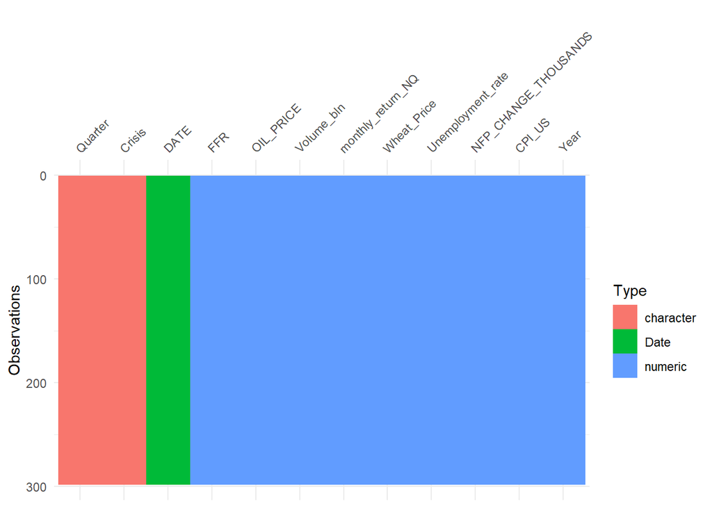

```r
vis_dat(dane_makroekonomiczne)
```

**Podsumowanie zmian**

- Zostaly dodane kolumny : Quarter , Year,Crisis CPI_US
- Zamieniony zostal typ danych NFP z character na numeric
- Dla podanych wyzej okresów odpowiednia nazwa kryzysu

**Quarter**

- Kwartał

**Crisis**

- Przypisuje typ kryzysu wedlug okresow wyzej wymienionych
- DOT-COM
- Peace
- GFC
- COVID
- RUSSIAN INVASION

**DATE**

- data

**Federal Funds Rate- FFR**

- Głowna stopa procentowa w USA
- Jest to stopa po ktorej banki komercyjne pozyczaja sobie swoje excess reserves
- excess reserve to rezerwy ktore bank komercyjny posiada po spelnieniu swoich capital requirements
- Jest to transakcja overnight czyli tą kwote która bank x od kogos pozyczyl musi zwrocic ja na drugi dzien po stopie FFR
- Kazdy bank w USA musi spelniac Capital requirements m.in Basel Acords czyli w uproszczeniu trzymac pewnia ilosc gotowki lub aktyw szybko zbywalnych.
- Jest to zabezpieczenie m.in przed tym aby bank mogl wytrzymac nieprzewidywalne sytuacje w postaci wzmozonej ilosci wyplacanych depozytów albo pokryc strate operacyjna.
- Im mniejsza stopa procentowa tym mniejsze wymagania musi spelnic bank co do trzymanej gotowki lub innych plynnych aktywow co daje mu mozliwosc pozyczania pieniedzy po tanszym koszcie co w efekcie powoduje , ze bank alokuje wieksze ilosci gotowki w np. akcje albo obligacje.
- FFR rowniez wplywa posrednio na Secured Overnight financing Rate (SOFR) czyli na stope benchmarkową po ktorej udziela sie kredytow np hipotecznych,studenckich lub konsumenckich etc w USA.

**Oil_PRICE**

- Ceny ropy naftowej WTI w $

**Volume_bln**

- Wolumen obrotu na indeksie Nasdaq.

**monthly_return_NQ**

- miesieczne zwroty z indeksu amrykańskiego Nasdaq.

**Wheat_Price**

- Ceny pszenicy za buszel w $

**Unemployment_rate**

- Stopa bezrobocia jest to zmiana w porownaniu do miesiaca z poprzedniego roku (YoY % change)

**NFP_CHANGE_THOUSANDS**

- Przyrost nowych miejsc pracy w sektorze pozarolniczym w USA

**CPI_US**

- Inflacja miesieczna CPI podobnie jak w przypadku stopy bezrobocia (YoY % change

**Year**

- Rok

# **Rynek pracy w USA**

- Bede analizowal rynek pracy w stanach zjednoczonych uzywajac dwoch glownych wskaznikow uzywanych przez FED :
- Stopy Bezrobocia i danych NFP

## **TEZA 1**

- Jak kryzys GFC wplynal na rynek pracy w USA?

## **TEZA 2**

- Czy istnieje korelacja miedzy stopa bezrobocia a danymi NFP podczas GFC?

**Zaczynamy od danych NFP**

```r
dane_do_tezy <-  dane_makroekonomiczne %>% select(DATE,NFP_CHANGE_THOUSANDS,Year,Unemployment_rate,Quarter,Crisis)


head(dane_do_tezy)
```

```
##         DATE NFP_CHANGE_THOUSANDS Year Unemployment_rate Quarter  Crisis
## 1 2000-01-01                  228 2000               4.0      Q1 Dot-Com
## 2 2000-02-01                  111 2000               4.1      Q1 Dot-Com
## 3 2000-03-01                  484 2000               4.0      Q1 Dot-Com
## 4 2000-04-01                  279 2000               3.8      Q2 Dot-Com
## 5 2000-05-01                  223 2000               4.0      Q2 Dot-Com
## 6 2000-06-01                  -46 2000               4.0      Q2 Dot-Com
```

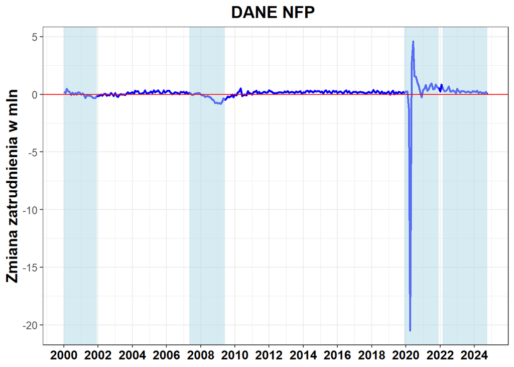

```r
ggplot(dane_do_tezy, aes(x = DATE, y = NFP_CHANGE_THOUSANDS/1000)) +
  geom_line(color = "blue",linewidth=1) +
  labs(title = "DANE NFP ",
       x = "Rok", y = "Zmiana zatrudnienia w mln") +
  theme_bw() +
  annotate("rect", xmin = as.Date("2007-05-01"), xmax = as.Date("2009-5-31"),
           ymin = -Inf, ymax = Inf, alpha = 0.5, fill = "lightblue") +
  annotate("rect", xmin = as.Date("2022-02-24"), xmax = as.Date("2024-10-01"),
           ymin = -Inf, ymax = Inf, alpha = 0.5, fill = "lightblue") +
  annotate("rect", xmin = as.Date("2000-01-01"), xmax = as.Date("2001-12-01"),
           ymin = -Inf, ymax = Inf, alpha = 0.5, fill = "lightblue") +
  annotate("rect", xmin = as.Date("2019-12-01"), xmax = as.Date("2021-12-01"),
           ymin = -Inf, ymax = Inf, alpha = 0.5, fill = "lightblue") +
  scale_x_date(date_breaks = "2 years", date_labels = "%Y") +
  theme(
    plot.title = element_text(hjust = 0.5, size = 16, face = "bold"),
    axis.text.x = element_text(size = 12,face="bold",color = "black"),
    axis.title.y = element_text(size = 15, face = "bold"),
    axis.text.y = element_text(size = 10),
    axis.title.x = element_blank(),
  )+geom_hline(yintercept = 0,color="red")
```

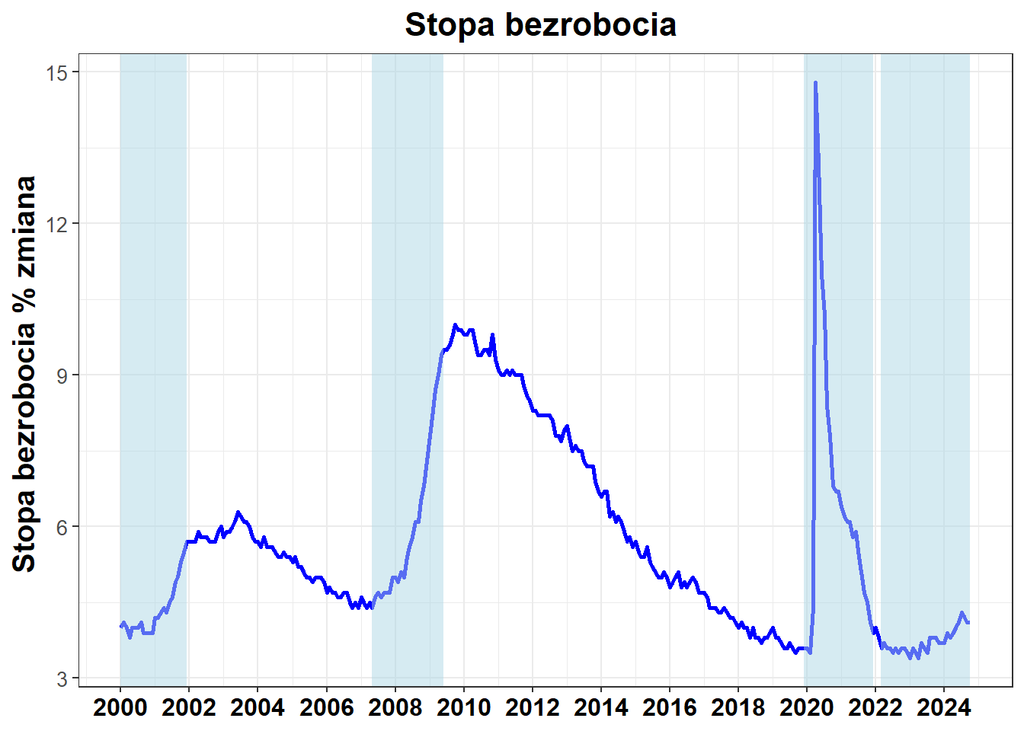

```r
ggplot(dane_do_tezy, aes(x = DATE, y = Unemployment_rate)) +
  geom_line(color = "blue",linewidth=1) +
  labs(title = "Stopa bezrobocia ",
       x = "Rok", y = "Stopa bezrobocia % zmiana ") +
  theme_bw() +
  annotate("rect", xmin = as.Date("2007-05-01"), xmax = as.Date("2009-05-31"),
           ymin = -Inf, ymax = Inf, alpha = 0.5, fill = "lightblue") +
  annotate("rect", xmin = as.Date("2022-02-24"), xmax = as.Date("2024-10-01"),
           ymin = -Inf, ymax = Inf, alpha = 0.5, fill = "lightblue") +
  annotate("rect", xmin = as.Date("2000-01-01"), xmax = as.Date("2001-12-01"),
           ymin = -Inf, ymax = Inf, alpha = 0.5, fill = "lightblue") +
  annotate("rect", xmin = as.Date("2019-12-01"), xmax = as.Date("2021-12-01"),
           ymin = -Inf, ymax = Inf, alpha = 0.5, fill = "lightblue") +
  scale_x_date(date_breaks = "2 years", date_labels = "%Y") +
   theme(
    plot.title = element_text(hjust = 0.5, size = 16, face = "bold"),
    axis.text.x = element_text(size = 12,face="bold",color = "black"),
    axis.title.y = element_text(size = 15, face = "bold"),
    axis.text.y = element_text(size = 10),
    axis.title.x = element_blank(),
  )
```

- Kolorem jasno-niebieskiem jest zaznaczony kazdy wymieniony kryzys.
- Okres covidu podbil stope bezrobocia do 15% i spowodowal zwolnienie ponad 20 mln ludzi. Co bylo spowodowane przez wprowadzony lockdown w USA i w innych krajach na calym swiecie .
- Po GFC i Dot-comie po duzym wzroscie mielismy stopniowe schodzenie z podwyzszonej stopy bezrobocia. Co wskazuje na to ze powrot przed kryzysowe rejony stopy bezrobocia zajmuje okolo kilka/kilkanasie lat.

**NFP W LATACH KRYZYSU GFC**

```r
dane_do_tezy_2 <- dane_do_tezy %>% filter(DATE >="2007-05-01" & DATE <="2009-05-31" )

head(dane_do_tezy_2)
```

```
##         DATE NFP_CHANGE_THOUSANDS Year Unemployment_rate Quarter Crisis
## 1 2007-05-01                  151 2007               4.4      Q2    GFC
## 2 2007-06-01                   79 2007               4.6      Q2    GFC
## 3 2007-07-01                  -30 2007               4.7      Q3    GFC
## 4 2007-08-01                  -25 2007               4.6      Q3    GFC
## 5 2007-09-01                   86 2007               4.7      Q3    GFC
## 6 2007-10-01                   72 2007               4.7      Q4    GFC
```

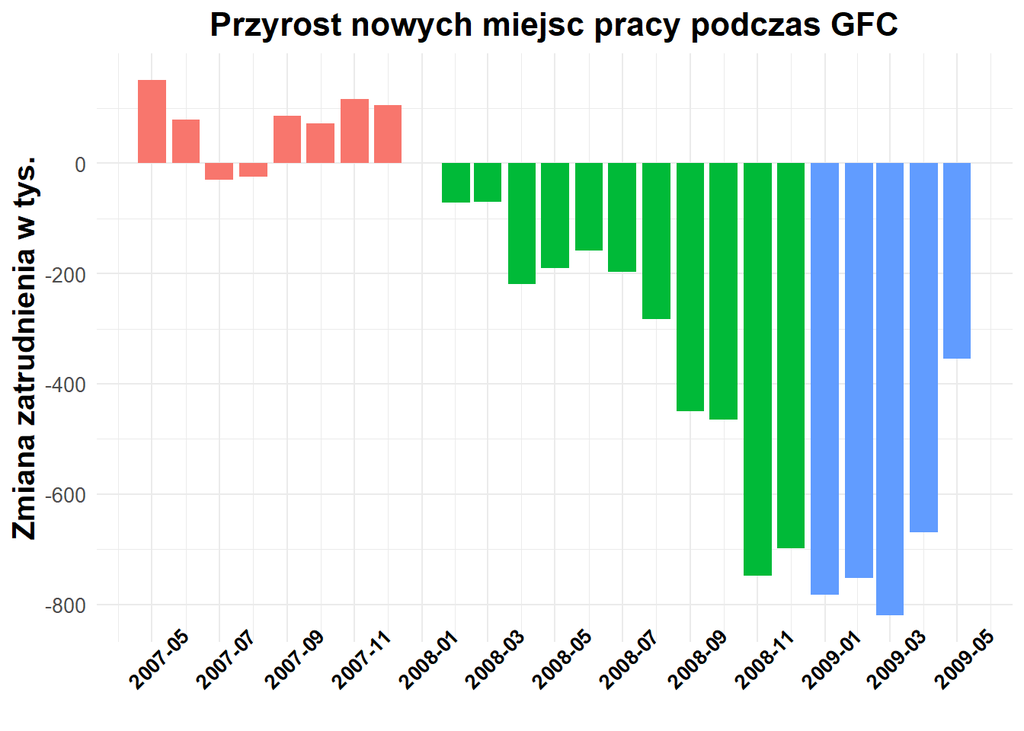

```r
ggplot(dane_do_tezy_2, aes(x = DATE, y = NFP_CHANGE_THOUSANDS, fill = as.factor(Year))) +
  geom_col() +
  labs(
    title = "Przyrost nowych miejsc pracy podczas GFC",
    x = "Rok",
    y = "Zmiana zatrudnienia w tys."
  ) +
  theme_minimal() +
  scale_x_date(date_breaks = "2 months", date_labels = "%Y-%m") +
  theme(
    plot.title = element_text(hjust = 0.5, size = 16, face = "bold"),
    axis.text.x = element_text(size = 10,face="bold",color = "black",angle = 45),
    axis.title.y = element_text(size = 15, face = "bold"),
    axis.text.y = element_text(size = 10),
    axis.title.x = element_blank(),
    legend.position = "none"

  )
```

```r
dane_do_tezy_2 %>% group_by(Year) %>%
  summarise(suma =sum(NFP_CHANGE_THOUSANDS),srednia=mean(NFP_CHANGE_THOUSANDS),mediana=median(NFP_CHANGE_THOUSANDS)) %>%
  arrange(Year)
```

```
## # A tibble: 3 × 4
##    Year  suma srednia mediana
##   <dbl> <dbl>   <dbl>   <dbl>
## 1  2007   554    69.2    82.5
## 2  2008 -3548  -296.   -208
## 3  2009 -3378  -676.   -752
```

```r
dane_do_tezy_2 %>% slice_min(NFP_CHANGE_THOUSANDS,n=5) %>% select(-Quarter,-Unemployment_rate)
```

```
##         DATE NFP_CHANGE_THOUSANDS Year Crisis
## 1 2009-03-01                 -820 2009    GFC
## 2 2009-01-01                 -782 2009    GFC
## 3 2009-02-01                 -752 2009    GFC
## 4 2008-11-01                 -748 2008    GFC
## 5 2008-12-01                 -698 2008    GFC
```

```r
dane_do_tezy_2 %>% slice_max(NFP_CHANGE_THOUSANDS,n=5)%>% select(-Quarter,-Unemployment_rate)
```

```
##         DATE NFP_CHANGE_THOUSANDS Year Crisis
## 1 2007-05-01                  151 2007    GFC
## 2 2007-11-01                  116 2007    GFC
## 3 2007-12-01                  105 2007    GFC
## 4 2007-09-01                   86 2007    GFC
## 5 2007-06-01                   79 2007    GFC
```

```r
print(sum(dane_do_tezy_2$NFP_CHANGE_THOUSANDS))
```

```
## [1] -6372
```

**Stopa bezrobocia**

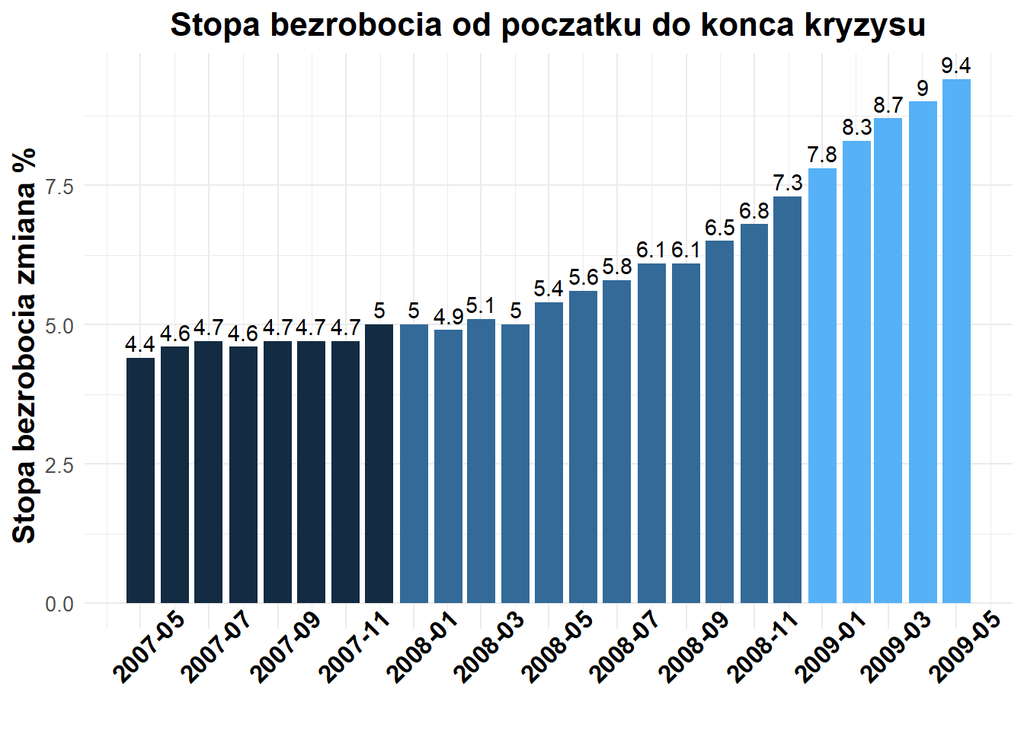

```r
ggplot(dane_do_tezy_2, aes(x = DATE, y = Unemployment_rate, fill =Year)) +
  geom_col() +
  labs(
    title = "Stopa bezrobocia od poczatku do konca kryzysu",
    x = "Rok",
    y = "Stopa bezrobocia zmiana % "
  ) +
  theme_minimal() +
  scale_x_date(date_breaks = "2 months", date_labels = "%Y-%m")+
   theme(
    plot.title = element_text(hjust = 0.5, size = 16, face = "bold"),
    axis.text.x = element_text(size = 12,face="bold",color = "black",angle =45),
    axis.title.y = element_text(size = 15, face = "bold"),
    axis.text.y = element_text(size = 10),
    axis.title.x = element_blank(),
    legend.position = "none"
  )  +geom_text(aes(label=Unemployment_rate,vjust=-0.4))
```

```r
dane_do_tezy_2 %>% group_by(Year) %>%
  summarise(srednia=mean(Unemployment_rate),mediana=median(Unemployment_rate)) %>% arrange(Year)
```

```
## # A tibble: 3 × 3
##    Year srednia mediana
##   <dbl>   <dbl>   <dbl>
## 1  2007    4.68     4.7
## 2  2008    5.8      5.7
## 3  2009    8.64     8.7
```

```r
summary(dane_do_tezy_2$Unemployment_rate)
```

```
##    Min. 1st Qu.  Median    Mean 3rd Qu.    Max.
##   4.400   4.700   5.400   6.008   6.800   9.400
```

```r
dane_do_tezy_2 %>% slice_min(Unemployment_rate,n=5)%>% select(-NFP_CHANGE_THOUSANDS,-Quarter)
```

```
##         DATE Year Unemployment_rate Crisis
## 1 2007-05-01 2007               4.4    GFC
## 2 2007-06-01 2007               4.6    GFC
## 3 2007-08-01 2007               4.6    GFC
## 4 2007-07-01 2007               4.7    GFC
## 5 2007-09-01 2007               4.7    GFC
## 6 2007-10-01 2007               4.7    GFC
## 7 2007-11-01 2007               4.7    GFC
```

```r
dane_do_tezy_2 %>% slice_max(Unemployment_rate,n=5) %>% select(-NFP_CHANGE_THOUSANDS,-Quarter)
```

```
##         DATE Year Unemployment_rate Crisis
## 1 2009-05-01 2009               9.4    GFC
## 2 2009-04-01 2009               9.0    GFC
## 3 2009-03-01 2009               8.7    GFC
## 4 2009-02-01 2009               8.3    GFC
## 5 2009-01-01 2009               7.8    GFC
```

```r
poczatek=min(dane_do_tezy_2$Unemployment_rate)

koniec = max(dane_do_tezy_2$Unemployment_rate)

round((koniec - poczatek)/poczatek,2)
```

```
## [1] 1.14
```

## **Podsumowanie Tezy 1**

- Kryzys wplynal zdecydowanie negatywnie na rynek pracy poniewaz podwyzszyl stope bezrobocia o 5 punktow bazowych i spowodowal utrate miejsc pracy 6,4 mln osob.
- Co zaskakujące nie powinno byc biorac pod uwage charakter kryzysu popytowego czyli upadki jednych z najwiekszych firm co oczywiscie generuje szereg innych negatywnych konsekwencji m.in masowe zwolnienia w roznych sektorach,bank-runy, upadek innych firm powiązanych , co przeklada sie na nizszy wzrost gospodarczy poprzez mniejsze inwestycje i mniejszą konsumpcje

**Czy istnieje korelacja między stopą bezrobocia a danymi NFP?**

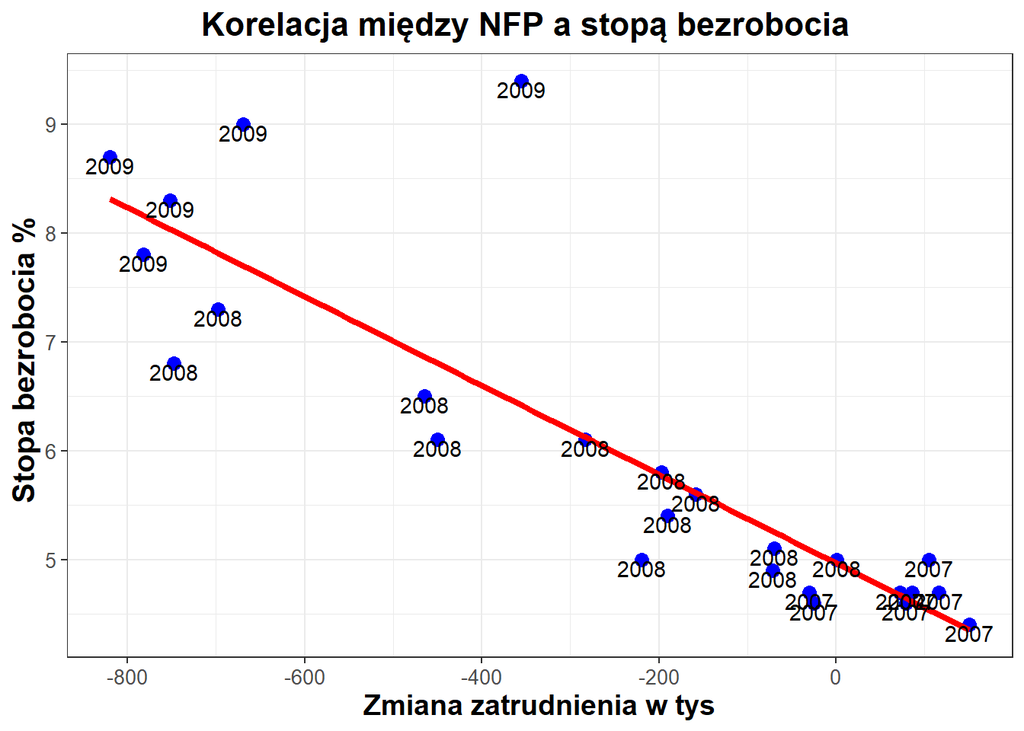

```r
ggplot(dane_do_tezy_2, aes(x = NFP_CHANGE_THOUSANDS, y = Unemployment_rate)) +
  geom_point(color = "blue", size = 3) +
  geom_smooth(method = "lm", se = FALSE, color = "red", linewidth = 1.5) +
  labs(
    title = "Korelacja między NFP a stopą bezrobocia   ",
    x = "Zmiana zatrudnienia w tys",
    y = "Stopa bezrobocia % "
  ) +
  theme_bw() +
 theme(
    plot.title = element_text(hjust = 0.5, size = 16, face = "bold"),
    axis.title.x = element_text(size = 14, face = "bold"),
    axis.text.x = element_text(size = 10),
    axis.title.y = element_text(size = 15, face = "bold"),
    axis.text.y = element_text(size = 10),
  )+geom_text(aes(label = Year,vjust=1))
```

```r
cor(dane_do_tezy_2$NFP_CHANGE_THOUSANDS,dane_do_tezy_2$Unemployment_rate)
```

```
## [1] -0.8606854
```

## **Podsumowanie TEZY 2**

- Podczas GFC wzrastala stopa bezrobocia a malalo zatrudnienie .
- Dodatkowo mamy silna ujemna korelacje -0.86

## **3 TEZA**

- Czy podczas kazdego kryzysu rynek pracy reagowal tak samo?

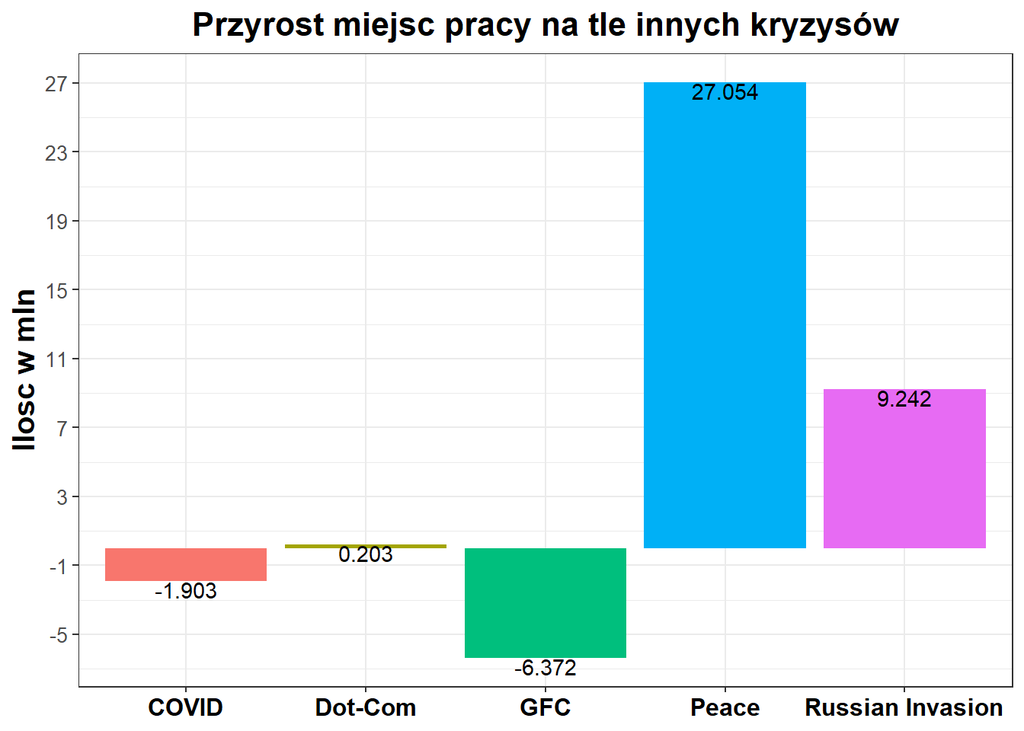

```r
kryzysy_2 <-  dane_do_tezy %>% group_by(Crisis) %>% summarise(total = sum(NFP_CHANGE_THOUSANDS))


ggplot(kryzysy_2, aes(x = Crisis, y = total/1000, fill = Crisis)) +
  geom_col() +
  labs(
    title = "Przyrost miejsc pracy na tle innych kryzysów",
    x = "Rodzaj kryzysu",
    y = "Ilosc w mln"
  ) +
  scale_y_continuous(breaks = seq(-9, max(kryzysy_2$total/1000), by = 4)) +
  theme_bw() +
 theme(
 plot.title = element_text(hjust = 0.5, size = 16, face = "bold"),
    axis.text.x = element_text(size = 12,face="bold",color = "black"),
    axis.title.y = element_text(size = 15, face = "bold"),
    axis.text.y = element_text(size = 10),
    axis.title.x = element_blank(),
    legend.position = "none"
  )  +geom_text(aes(label=total/1000,vjust = 1))
```

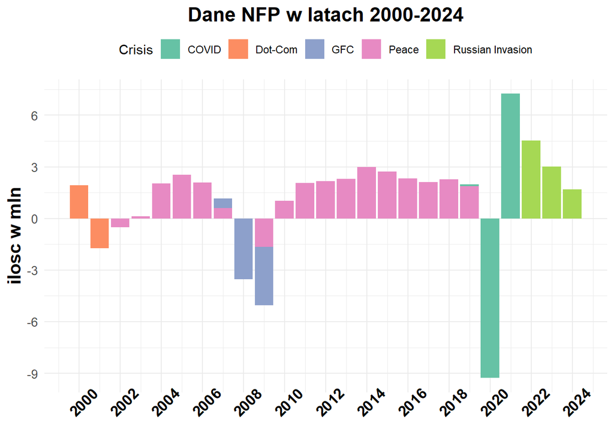

```r
kryzysy <- dane_do_tezy %>% group_by(Year,Crisis) %>% summarise(total_year = sum(NFP_CHANGE_THOUSANDS),.groups = "drop")

ggplot(kryzysy, aes(x = Year, y = total_year/1000, fill = Crisis)) +
  geom_col() +
  labs(
    title = "Dane NFP w latach 2000-2024",
    y = "ilosc w mln"
  ) +
  scale_y_continuous(breaks = seq(-9, max(kryzysy$total_year/1000), by = 3)) +
  scale_x_continuous(breaks = seq(min(kryzysy$Year), max(kryzysy$Year), by = 2)) +
  theme_minimal() +
  scale_fill_brewer(palette = "Set2")+
  theme(
    plot.title = element_text(hjust = 0.5, size = 16, face = "bold"),
    axis.text.x = element_text(size = 12,face="bold",color = "black",angle=45),
    axis.title.y = element_text(size = 15, face = "bold"),
    axis.text.y = element_text(size = 10),
    axis.title.x = element_blank(),
    legend.position = "top"
  )
```

**Dlaczego?**

- Ponieważ mielismy liczne programy stymulacyjne gosopodarke podczas Covidu w latach 2020-2021 ktore dodaly ogromną ilość płynności do konsumentów, firm jak i instytyucji rządowych, takie jak:

**Cares Act**

- https://en.wikipedia.org/wiki/CARES_Act
- Ktory opiewał na kwote 2.2 tryliona dolarow i mieędzy innymi:
- 300 mld dolarow bezpośrednich czeków dla obywateli.
- 260 mld w celu zwiększenia zasiłku dla bezrobotnych.
- 669 mld forgivable loans dla malych biznesow ktorych kwota splaty pozyczki moze byc w czesci lub calkowicie uniewazniona.
- 500 mld pozyczek dla firm .
- 340 mld dotacji dla stanów i włazd lokalnych najnizszego szczebla.

**Paycheck Protection Program and Health Care Enhancement Act**

- https://en.wikipedia.org/wiki/Paycheck_Protection_Program_and_Health_Care_Enhancement_Act
- Kwota 500mld dolarow roszezrenie pozyczek z Care act dla malych firm.

**Consolidated Appropriations Act**

- https://en.wikipedia.org/wiki/Consolidated_Appropriations_Act,_2021
- Rozszerzenie Cares act na podobne obszary czyli: kosnumentow,firmy,instytycje rzadowe ,stany etc
- Kwota bezposredniego pakietu to 2.3 tryliona dolarow

**American Rescue Plan Act**

- https://en.wikipedia.org/wiki/American_Rescue_Plan_Act_of_2021
- Kolejny pakiet stymulacyjny ktory opiewał na kwote 1,9 tryliona dolarow
- Dodatkowe Czeki dla obywateli, rozszserzenie zasilkow dla bezrobotnych, instytucji rzadkow, malych biznesow,szkoł szpitali etc

**Inflation Reduction Act**

- https://en.wikipedia.org/wiki/Inflation_Reduction_Act
- 891 mld dolarow wydatkow
- Glownie chodzilo o przeciwdzialanie zmianom klimatycznym w postaci promowanie czystej energii poprzez np. dotacje do produkcji samochodow elektrycznych,zachet do inwestycji w zielona energie .Wprowadzenie nowych podatkow w postaci np podatku 1% od skupu wlasnych akcji. etc.
- Ma na celu zapewnić tworzenie nowych miejsce pracy w sektorze Greenfield.

**INNE**

**QE**

- Polega na skupie securities(papierów wartosciowych) przez Bank centralny (głownie rządowych i Mortgage backed securities) na rynku wtórnym.
- Co to MBS? to papiery wartosciowe ktore sa tworzone poprzez sekurtyzacje czyli przeksztalcenie aktyw (np kredytu hipotecznego) w papiery wartosciowe ktore mozna sprzedac np 100 dolarow za sztuke z 5% oprocentowaniem,
- Banki przeksztalcaja kredyty hipoteczne w papier MBS.
- Skup papierow wartosciowych na kwote prawie 5 trylionów dolarów (Aktywa w bilansie Fedu)
- https://fred.stlouisfed.org/seriesBeta/WALCL

**Chips and Science ACT**

- https://en.wikipedia.org/wiki/CHIPS_and_Science_Act
- Kwota okolo 280 mld dolarow przeznaczona na badanie naukowe odnosnie polprzeownikow i nowych technologii np. lotów kosmicznych i komputerów kwantowych
- Podobnie jak IRA ma na celu również tworzenie nowych miejsc pracy.

**Bank Reserve ratio**

- Porównujac do polski to stopa depozytowa.
- Stopa po ktorej banki musza trzymac okreslona ilosc gotowki bezposrednio na kontach w Fed.
- Obliczana jako aktywa*stopa.
- Fed obnizyl ja do 0% podczas Covidu co dodalo kolejnych wolnych srodkow bankom do kreowania kredytow lub innych inwestycji.

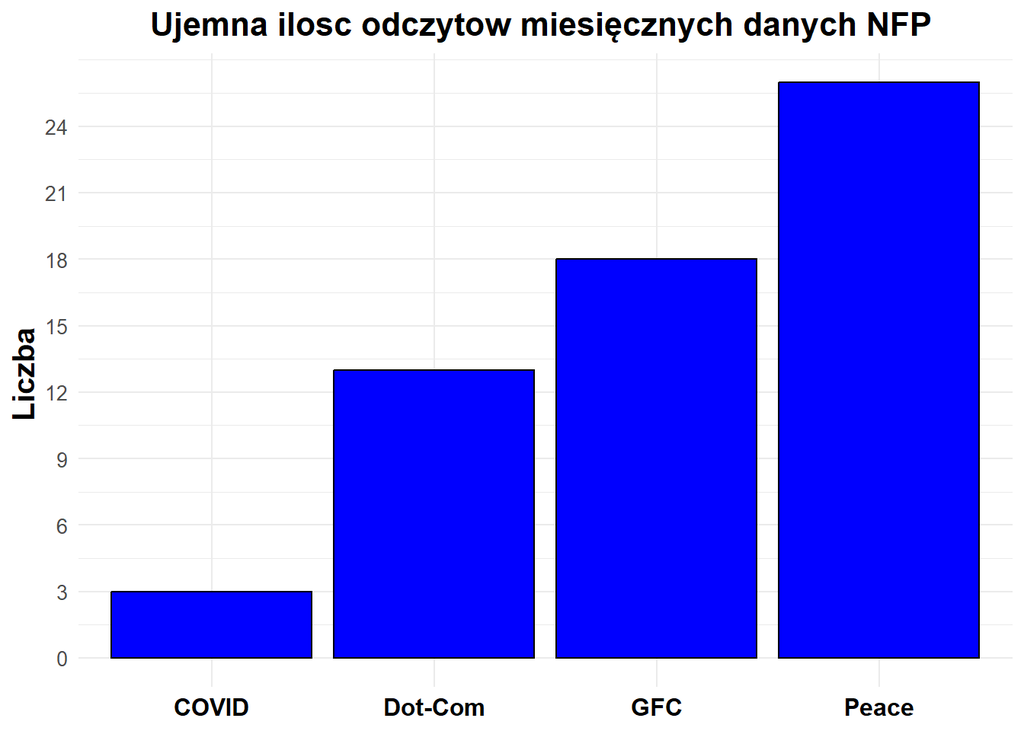

```r
ujemne_Nfp <- dane_do_tezy %>% filter(NFP_CHANGE_THOUSANDS <=0)

ggplot(ujemne_Nfp, aes(x = Crisis)) +
  geom_bar(fill = "blue", color = "black") +
  scale_y_continuous(breaks = seq(0, max(table(ujemne_Nfp$Crisis)), by = 3)) +
  labs(
    title = "Ujemna ilosc odczytow miesięcznych danych NFP ",
    x = "Kryzys",
    y = "Liczba "
  ) +
  theme_minimal() +
  theme(
    plot.title = element_text(hjust = 0.5, size = 16, face = "bold"),
    axis.text.x = element_text(size = 12,face="bold",color = "black"),
    axis.title.y = element_text(size = 15, face = "bold"),
    axis.text.y = element_text(size = 10),
    axis.title.x = element_blank(),
  )
```

- **Okres inwazji Rosji na ukraine nie zanotował ani jednego ujemnego miesiaca przyrostu miejsc pracy**

```r
dattt <- dane_do_tezy %>% group_by(Year,Crisis) %>%
  summarise(mean_year = mean(Unemployment_rate),
            median_year = median(Unemployment_rate), .groups = "drop")


head(dattt)
```

```
## # A tibble: 6 × 4
##    Year Crisis  mean_year median_year
##   <dbl> <chr>       <dbl>       <dbl>
## 1  2000 Dot-Com      3.97        4
## 2  2001 Dot-Com      4.74        4.55
## 3  2002 Peace        5.78        5.75
## 4  2003 Peace        5.99        6
## 5  2004 Peace        5.54        5.55
## 6  2005 Peace        5.08        5
```

```r
sum(dane_do_tezy$NFP_CHANGE_THOUSANDS/1000)
```

```
## [1] 28.224
```

```r
dane_do_tezy %>% filter(Crisis =="COVID", NFP_CHANGE_THOUSANDS <=0)
```

```
##         DATE NFP_CHANGE_THOUSANDS Year Unemployment_rate Quarter Crisis
## 1 2020-03-01                -1411 2020               4.4      Q1  COVID
## 2 2020-04-01               -20477 2020              14.8      Q2  COVID
## 3 2020-12-01                 -243 2020               6.7      Q4  COVID
```

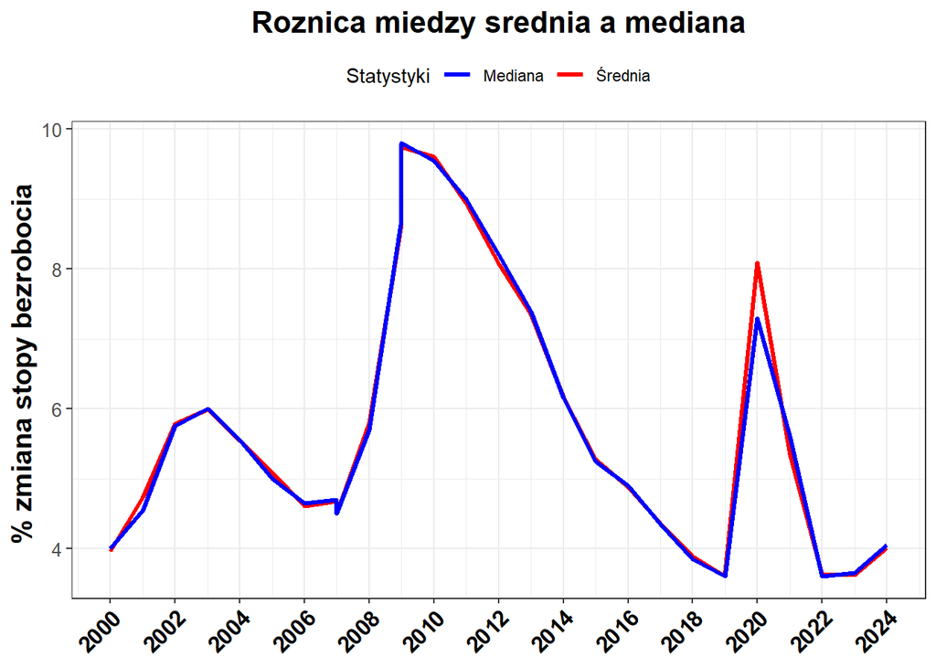

```r
  ggplot(dattt, aes(x = Year)) +
    geom_line(aes(y = mean_year, color = "Średnia"), linewidth = 1.2) +
    geom_line(aes(y = median_year, color = "Mediana"), linewidth = 1.2) +
    scale_color_manual(values = c("Średnia" = "red", "Mediana" = "blue")) +
   scale_x_continuous(breaks = seq(min(dattt$Year), max(dattt$Year), by = 2)) +
    labs(
      title = "Roznica miedzy srednia a mediana",
      x = "Rok",
      y = "% zmiana stopy bezrobocia ",
      color = "Statystyki"
    ) +
    theme_bw() +
  theme(
    plot.title = element_text(hjust = 0.5, size = 16, face = "bold"),
    axis.text.x = element_text(hjust = 1, size = 12,angle = 45,color="black",face="bold"),
    axis.title.x = element_blank(),
    axis.title.y = element_text(size = 15, face = "bold"),
    axis.text.y = element_text(size = 10),
    legend.position = "top"

    )
```

```r
dane_do_tezy %>% slice_max(Unemployment_rate,n=5) %>% select(-NFP_CHANGE_THOUSANDS)
```

```
##         DATE Year Unemployment_rate Quarter Crisis
## 1 2020-04-01 2020              14.8      Q2  COVID
## 2 2020-05-01 2020              13.2      Q2  COVID
## 3 2020-06-01 2020              11.0      Q2  COVID
## 4 2020-07-01 2020              10.2      Q3  COVID
## 5 2009-10-01 2009              10.0      Q4  Peace
```

```r
dane_do_tezy %>% slice_min(Unemployment_rate,n=5) %>% select(-NFP_CHANGE_THOUSANDS)
```

```
##         DATE Year Unemployment_rate Quarter           Crisis
## 1 2023-01-01 2023               3.4      Q1 Russian Invasion
## 2 2023-04-01 2023               3.4      Q2 Russian Invasion
## 3 2019-09-01 2019               3.5      Q3            Peace
## 4 2020-02-01 2020               3.5      Q1            COVID
## 5 2022-07-01 2022               3.5      Q3 Russian Invasion
## 6 2022-09-01 2022               3.5      Q3 Russian Invasion
## 7 2022-12-01 2022               3.5      Q4 Russian Invasion
## 8 2023-03-01 2023               3.5      Q1 Russian Invasion
## 9 2023-07-01 2023               3.5      Q3 Russian Invasion
```

```r
dane_do_tezy %>% group_by(Crisis) %>% summarise(correlation = cor(NFP_CHANGE_THOUSANDS,Unemployment_rate))
```

```
## # A tibble: 5 × 2
##   Crisis           correlation
##   <chr>                  <dbl>
## 1 COVID                 -0.416
## 2 Dot-Com               -0.763
## 3 GFC                   -0.861
## 4 Peace                 -0.277
## 5 Russian Invasion      -0.389
```

## **Podsumowanie 3 tezy**

- Podsumowuajac nie reagował tak samo ,poniewaz rózniły się one po pierwsze dlugoscia. Okres Russian Invasion trwa juz ponad 2 lata, natomiast Gfc Covid,dotcom trwaly okolo 2 lata.
- wpływem na dane NFP i stope bezrobocia, ponieważ podczas kryzysu Russian Agression stopa bezrobocia wzrosła minimalnie a rynek pracy dodał około 9,2 mln nowych miejsc pracy. W porownaniu do innych byl to jedyny okres z tak duzym wzrostem nowych miejsc pracy a takze ani razu nie wystapil miesiac w którym rynek pracy zanotował ujemny przyrost
- Kryzysy GFC , Dot-com i COVID sa typowo kryzysami popytowymi natomiast Russian invasion podazowym czyli byl spowodowany m.in wzrostem cen ropy.
- kryzys Dot-com byl najlżejszy ponieważ mielismy podczas niego najemniejszy wzrost stopy bezrobocia i najmniejszy ujemny przyrost miejsc pracy.
- GFC byl kryzysem który najbardziej negatywnie wpłynał na rynek pracy. Ponieważ spowodował wzrost o 5 punktow bazowych stopy bezrobocia i utraty 6.4 mln miejsc pracy.
- Korelacje podczas badanych okresów różniły się siłą jednakze kierunek zawsze pozostawał ten sam.
- Pomimo tego ze okres Peace mial najwieksza ilosc ujemnych odczytow NFP to dodal najwieksza ilosc miejsc pracy.
- Co pokazuje ze mogly wystapic pewne pojedyncze zjawiska ktore pominalem a mogly wplynac negatywnie na przyrost miejsc pracy np Banking Crisis, Cyklony na wschodnim wybrzeżu USA etc.
- Lacznie pakiety stymulacyjne wprowadzone podczas kryzysu opiewały na kwote około 8 trylionów dolarów, uwzgledniając oczywiscie same wydatki rządowe poniesione przez Skarb państwa. Jednakże trzeba doliczyć również QE przeprowadzone przez FED na kwote od poczatku Covidu do jego jego maksymalnej wartosci czyli 5 trylionow.
- Łączna kwota najważniejszych programów płynnościowych to 13 trylionów dolarów wliczając Skarb państwa i Bank Centralny.
- Covid mial tylko 3 ujemne odczyty a odjal -1.9 mln miejsc pracy, co wskazuje ze wprowadzone pakiety stymulacyjne szybko podniosly gospodarke USA.
- Dodatkowo COVID byl jedynym okresem w ktorym srednia stopa bezrobocia znaczaco roznila sie od mediany.
- W latach 2000-2024 pomimo kryzysow stany zjednoczone dodaly 28,2 milionów nowych miejsc pracy.
- *Czemu najnizsza stopa bezrobocia byla podczas RUSSIAN INVASION a nie PEACE?*
- Poniewaz wpływ pakietów stymulacyjnych nadal jest obecny w latach 2022-2023 natomiast w 2024 juz mniej ponieważ widac wzrost stopy bezrobocia jak i wolniejszy przyrost nowych miejsc pracy. Dodatkowo po Kryzysach dot-com jak i Gfc stopa bezrobocia stopniowo latami schodzila z podwyższonych poziomów.

# **Stopy Procentowe**

## **TEZA 4**

- W ktorym roku podczas GFC obniżono najszybciej stopy procentowe?

## **TEZA 5**

- Czy podczas kazdego kryzysu stopy procentowe były podwyższane?

```r
FFRrates <-  dane_makroekonomiczne %>% select(DATE,FFR,Year,Quarter,Crisis)



# dodanie kolumny FFR_CUT jako przypisane dla odpowiedniej wartosci stopy procentowej jednego z labeli
FFRrates$FFR_cut <- cut(FFRrates$FFR, breaks = c(0, 2, 4, Inf),  labels = c("Low", "Medium", "High"),
                        include.lowest = TRUE)

head(FFRrates)
```

```
##         DATE  FFR Year Quarter  Crisis FFR_cut
## 1 2000-01-01 5.45 2000      Q1 Dot-Com    High
## 2 2000-02-01 5.73 2000      Q1 Dot-Com    High
## 3 2000-03-01 5.85 2000      Q1 Dot-Com    High
## 4 2000-04-01 6.02 2000      Q2 Dot-Com    High
## 5 2000-05-01 6.27 2000      Q2 Dot-Com    High
## 6 2000-06-01 6.53 2000      Q2 Dot-Com    High
```

```r
dane_do_tezy_3 <- FFRrates %>% filter(DATE >="2007-05-01" & DATE <="2009-05-31" )
```

**Wartosci przedzialow dla FFR**

- Nie uwzglednialem ujemnych stop procentowych poniewaz nie wystapily one ani razu w badanym okresie
- Przyjalem umowna granice w stopach procentowych:

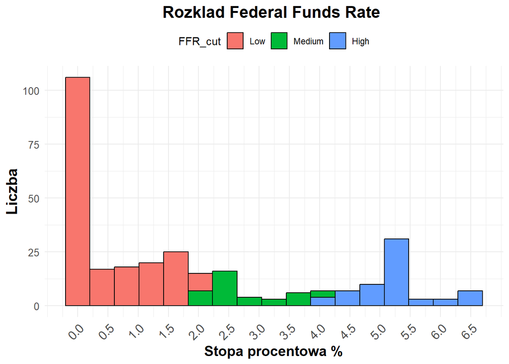

```r
ggplot(FFRrates, aes(x = FFR, fill = FFR_cut)) +
  geom_histogram(bins =round(sqrt(length(FFRrates$DATE))) , color = "black") +
  labs(
    title = "Rozklad Federal Funds Rate ",
    x = "Stopa procentowa %",
    y = "Liczba",
  ) +
  theme_minimal() +
  scale_x_continuous(breaks = seq(0, max(FFRrates$FFR), by = 0.5))+
   theme(
    plot.title = element_text(hjust = 0.5, size = 16, face = "bold"),
    axis.title.x = element_text(size = 14, face = "bold"),
    axis.text.x = element_text(hjust = 1, size = 12,angle = 45),
    axis.title.y = element_text(size = 15, face = "bold"),
    axis.text.y = element_text(size = 10),
    legend.position  = "top"
  )
```

```r
FFRrates %>% group_by(FFR_cut) %>% summarise(quantity = n())
```

```
## # A tibble: 3 × 2
##   FFR_cut quantity
##   <fct>      <int>
## 1 Low          194
## 2 Medium        39
## 3 High          65
```

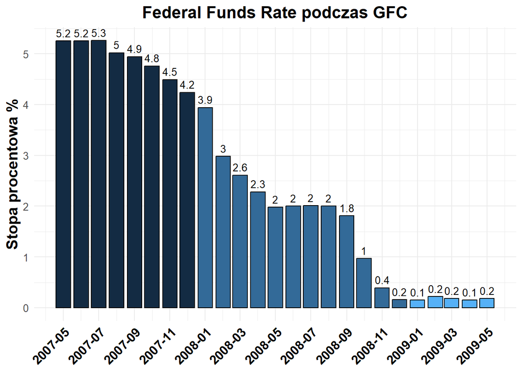

```r
ggplot(dane_do_tezy_3, aes(DATE, FFR, fill = Year)) +
  geom_bar(stat = "identity", color = "black", linewidth = 0.5) +
  geom_text(aes(label = round(FFR, 1)), vjust = -0.5, size = 3.5) +
  labs(
    title = "Federal Funds Rate podczas GFC",
    y = "Stopa procentowa %",
  ) +
  theme_minimal() +
  theme(
    plot.title = element_text(hjust = 0.5, size = 16, face = "bold"),
    axis.text.x = element_text(hjust = 1, size = 12,angle = 45,color="black",face="bold"),
    axis.title.x = element_blank(),
    axis.title.y = element_text(size = 15, face = "bold"),
    axis.text.y = element_text(size = 10),
    legend.position = "none"
    )+
  scale_x_date(
  date_breaks = "2 months",
  date_labels = "%Y-%m"
)
```

## **Podsumwanie tezy 4**

- Stopy procentowe najszybciej obnizono w roku 2008, poniewaz wtedy zaczely się największe problemy pokroju bankructwa Lehman Brothers,Washington Mutual i AIG.
- Najwieksze obinzki bo az o 100pb mialy miejsce w wrzesniu 2008 w szczegolnosci jedna we po upadku wyzej wymienionych firm.
- Fed musial obnizyc stopy procentowe aby zareagowac na pogaraszajaca sie sytaucje gospodarcza aby m.in
- Zmiejszyc oprocentowanie kredytów glownie hipoteczych ktore byly przyczyna wybuchu kryzysu. Oraz aby zapewnic tanie finansowanie firmą które borykały się z problemami plynnościowymi.
- W ciagu roku stopy zostaly obnizone z 4% do 0.2%.

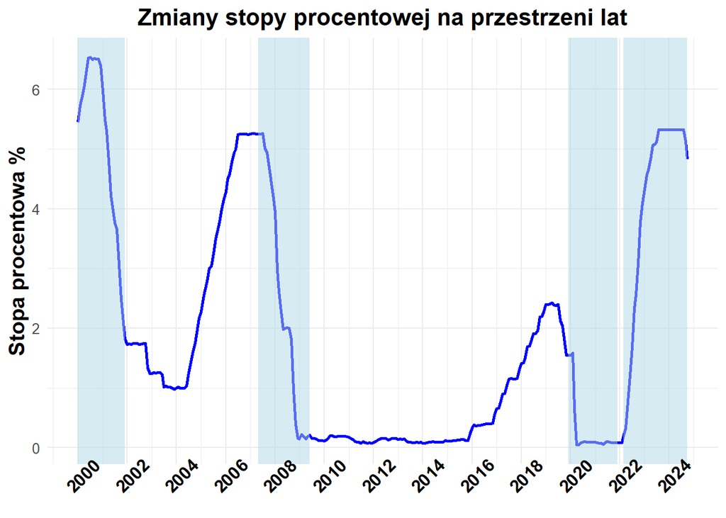

```r
ggplot(FFRrates, aes(x = DATE, y = FFR)) +
  geom_line(color = "blue", linewidth = 1) +
  labs(
    title = "Zmiany stopy procentowej na przestrzeni lat",
    x = "Data ",
    y = "Stopa procentowa %"
  ) +
  theme_minimal() +
   theme(
    plot.title = element_text(hjust = 0.5, size = 16, face = "bold"),
    axis.text.x = element_text(size = 12,face="bold",color = "black",angle =45),
    axis.title.y = element_text(size = 15, face = "bold"),
    axis.text.y = element_text(size = 10),
    axis.title.x = element_blank()
  )  +
   scale_x_date(
    date_breaks = "2 years",
    date_labels = "%Y"
  ) +
  annotate("rect", xmin = as.Date("2007-05-01"), xmax = as.Date("2009-05-31"),
           ymin = -Inf, ymax = Inf, alpha = 0.5, fill = "lightblue") +
  annotate("rect", xmin = as.Date("2022-02-24"), xmax = as.Date("2024-10-01"),
           ymin = -Inf, ymax = Inf, alpha = 0.5, fill = "lightblue") +
  annotate("rect", xmin = as.Date("2000-01-01"), xmax = as.Date("2001-12-01"),
           ymin = -Inf, ymax = Inf, alpha = 0.5, fill = "lightblue") +
  annotate("rect", xmin = as.Date("2019-12-01"), xmax = as.Date("2021-12-01"),
           ymin = -Inf, ymax = Inf, alpha = 0.5, fill = "lightblue")
```

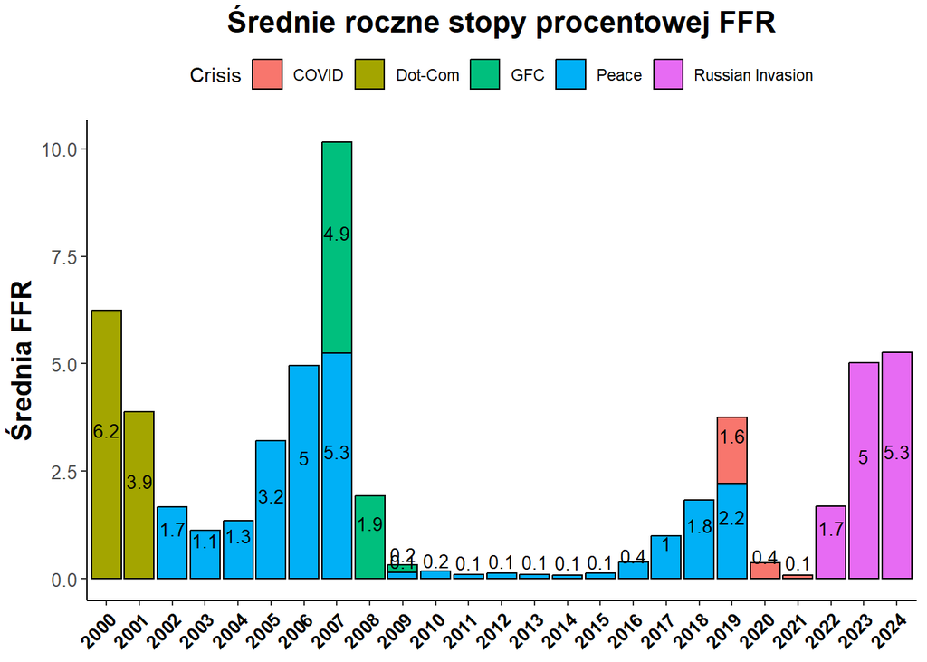

```r
by_year_FFR <- FFRrates %>% group_by(Year, Crisis) %>%
  summarize(avg_FFR = mean(FFR), .groups = "drop")



  ggplot(by_year_FFR, aes(as.factor(Year), avg_FFR, fill = Crisis)) +
    geom_bar(stat = "identity", color = "black") +
    geom_text(aes(label = round(avg_FFR, 1)),
              vjust = -0.5,
              size = 3.5,
              color = "black",
              position = position_stack(vjust = 0.5)) +
    labs(
      title = "Średnie roczne stopy procentowej FFR",
      x = "Rok",
      y = "Średnia FFR"
    ) +

    theme_classic() +
    theme(
      axis.text.x = element_text(angle = 45, hjust = 1, size = 10,face = "bold",color = "black"),
      axis.text.y = element_text(size = 10),
      plot.title = element_text(hjust = 0.5, size = 16, face = "bold"),
      axis.title.x = element_blank(),
      axis.title.y = element_text(size = 15, face = "bold"),
      legend.position = "top",

    )
```

```r
inflacja_cpi <- dane_makroekonomiczne %>% select(DATE,CPI_US)

head(inflacja_cpi)
```

```
##         DATE  CPI_US
## 1 2000-01-01 2.79296
## 2 2000-02-01 3.21797
## 3 2000-03-01 3.76214
## 4 2000-04-01 3.01386
## 5 2000-05-01 3.13253
## 6 2000-06-01 3.73494
```

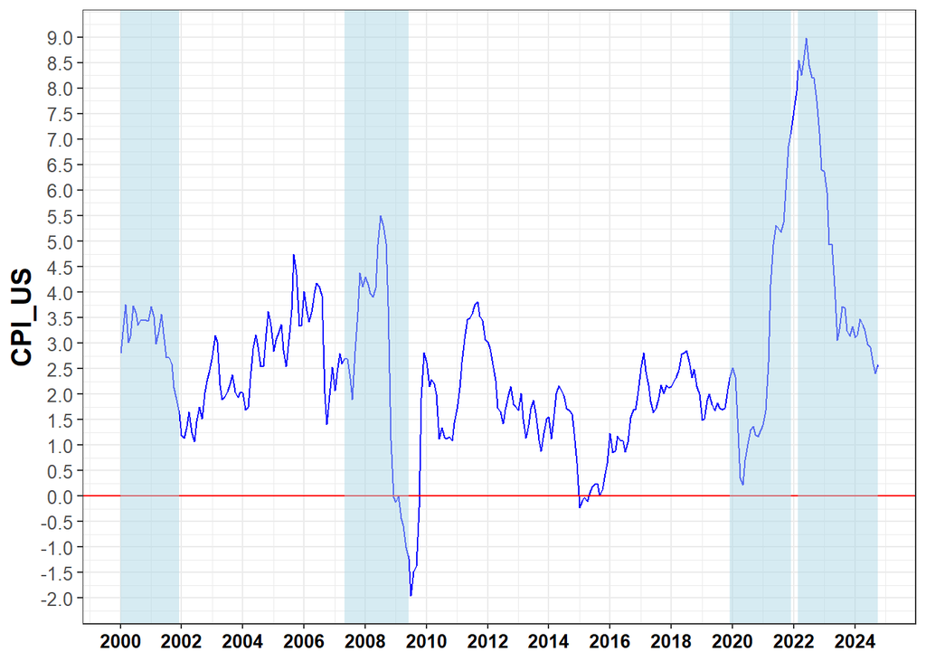

```r
ggplot(inflacja_cpi,aes(DATE,CPI_US))+geom_line(color="blue")+
   theme_bw() +
   theme(
    plot.title = element_text(hjust = 0.5, size = 16, face = "bold"),
    axis.text.x = element_text(size = 10,face="bold",color = "black"),
    axis.title.y = element_text(size = 15, face = "bold"),
    axis.text.y = element_text(size = 10),
    axis.title.x = element_blank()
  )  +
  scale_y_continuous(breaks = seq(floor(min(inflacja_cpi$CPI_US)),
                                  ceiling(max(inflacja_cpi$CPI_US)), by = 0.5))+
   scale_x_date(
    date_breaks = "2 years",
    date_labels = "%Y"
  ) +
  geom_hline(yintercept = 0,color="red")+
  annotate("rect", xmin = as.Date("2007-05-01"), xmax = as.Date("2009-05-31"),
           ymin = -Inf, ymax = Inf, alpha = 0.5, fill = "lightblue") +
  annotate("rect", xmin = as.Date("2022-02-24"), xmax = as.Date("2024-10-01"),
           ymin = -Inf, ymax = Inf, alpha = 0.5, fill = "lightblue") +
  annotate("rect", xmin = as.Date("2000-01-01"), xmax = as.Date("2001-12-01"),
           ymin = -Inf, ymax = Inf, alpha = 0.5, fill = "lightblue") +
  annotate("rect", xmin = as.Date("2019-12-01"), xmax = as.Date("2021-12-01"),
           ymin = -Inf, ymax = Inf, alpha = 0.5, fill = "lightblue")
```

## **Podsumowanie tezy 5**

- Nie podwyzszano stóp procentowych podczas kazdego kryzysu.Jedynym kryzysem podczas ktorego stopy procentowe byly podwyzszane to RUSSIAN AGRESSION , jest to spowodowane cenami surowców i energii ktore byly odpowiedzialne za inflacje w okresie 2022-24 a takze pakietem stymulacyjnym poniewaz inflacja zaczela nam rosnac przed rozpoczeciem wojny na ukrainie.
- Jednakze niewiadomo który z tych czynników miał przeważajacy wpływ.
- Podczas kryzysow popytowych stopy byly zawsze obnizane,poniewaz wchodzono w kryzys z wysokimi stopami (GFC i dot-com). W badanym okresie mielisimy do czynienia tylko z jednym kryzyem podazowym (RUSSIAN AGRESSION).
- Najwyzsze stopy procentowe mielismy podczas kryzysu dot-com.
- Jedyny spokojny okres mielismy po gfc od 2010- 2016 gdzie stopy procentowe byly na niemalze na zerowym poziomie
- W 2015 i 2016 roku stopy procentowe zaczely znowu nieznacznie rosnac, mozliwa przyczyna tego to wprowadzone przez Donalda Trumpa w 2018 roku cła na panele solarne i pralki
- https://en.wikipedia.org/wiki/China%E2%80%93United_States_trade_war
- Jednkaze bardziej prawdopodobną przeyczyną jest to ,że stopy podniesiono w 2015 i 2016 roku ponieważ mieliśmy znikomy przyrost cen a takze przez pewien okres deflacje (spadek cen).
- Dodatkowo najkrócej zostawalismy przy rekordowo wysokich stopach procentowych (oklice 5 punktow bazowych),co swiadczy o tym ze gospodarka USA wzglednie szybko radzila sobie z kryzysami popytowymi w porownaniu np do Turcji lub Polski. Inne podejscie np polski w kontekscie metod walki z inflacja ponieważ w polsce m.in mrożono ceny energii, obniżano vat na zywnosc etc.

# **Ropa I pszenica**

## **TEZA 6**

- Czy istnieje korelacja pomiędzy cenami ropy a cenami pszenicy,czy jest ona sezonowa?

## **TEZA 7**

- Które kryzysy spowodawały spadki cen ropy i pszenicy?

```r
ropa_i_pszenica <- dane_makroekonomiczne %>% select(OIL_PRICE,Wheat_Price,DATE,Quarter,Year,Crisis)

ropa_i_pszenica <- ropa_i_pszenica %>% mutate(Month = month(DATE))

head(ropa_i_pszenica)
```

```
##   OIL_PRICE Wheat_Price       DATE Quarter Year  Crisis Month
## 1  27.22429    93.62286 2000-01-01      Q1 2000 Dot-Com     1
## 2  29.36238    98.16683 2000-02-01      Q1 2000 Dot-Com     2
## 3  29.89217    96.39621 2000-03-01      Q1 2000 Dot-Com     3
## 4  25.79900    94.43122 2000-04-01      Q2 2000 Dot-Com     4
## 5  28.83348    99.11205 2000-05-01      Q2 2000 Dot-Com     5
## 6  31.85909   103.36661 2000-06-01      Q2 2000 Dot-Com     6
```

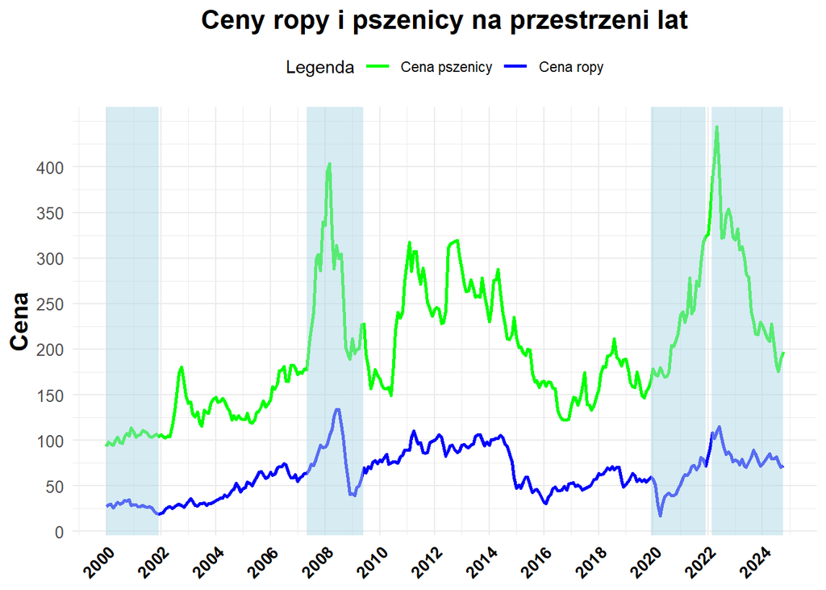

```r
ggplot(ropa_i_pszenica, aes(x = DATE,y=OIL_PRICE,color="Cena ropy")) +
  geom_line(linewidth = 1) +
  geom_line(aes(y = Wheat_Price, color = "Cena pszenicy"), linewidth = 1) +
  annotate("rect", xmin = as.Date("2007-05-01"), xmax = as.Date("2009-05-31"),
           ymin = -Inf, ymax = Inf, alpha = 0.5, fill = "lightblue") +
  annotate("rect", xmin = as.Date("2022-02-24"), xmax = as.Date("2024-10-01"),
           ymin = -Inf, ymax = Inf, alpha = 0.5, fill = "lightblue") +
  annotate("rect", xmin = as.Date("2000-01-01"), xmax = as.Date("2001-12-01"),
           ymin = -Inf, ymax = Inf, alpha = 0.5, fill = "lightblue") +
  annotate("rect", xmin = as.Date("2019-12-01"), xmax = as.Date("2021-12-01"),
           ymin = -Inf, ymax = Inf, alpha = 0.5, fill = "lightblue") +
  labs(
    title = "Ceny ropy i pszenicy na przestrzeni lat",
    y = "Cena",
    color = "Legenda"
  ) +
  scale_y_continuous(
    breaks = seq(0, max(ropa_i_pszenica$Wheat_Price) , by = 50)
  )+
  scale_color_manual(values = c("Cena ropy" = "blue", "Cena pszenicy" = "green")) +
   scale_x_date(
    date_breaks = "2 years",
    date_labels = "%Y"
  ) +
  theme_minimal() +
  theme(
      axis.text.x = element_text(angle = 45, hjust = 1, size = 10,face = "bold",color = "black"),
      axis.text.y = element_text(size = 10),
      plot.title = element_text(hjust = 0.5, size = 16, face = "bold"),
      axis.title.x = element_blank(),
      axis.title.y = element_text(size = 15, face = "bold"),
      legend.position = "top",
    )
```

- Podczas kryzysu Dot-com ceny ropy kompletnie nie zareagowaly.
- W GFC Zastanawiajacy jest wzrost cen pszenicy i ropy , tutaj zapewne sytuacja na blskim wschodzie lub tez ogranicznie podazy ropu przez kartel OPEC mial swoj wplyw.
- Po najwiekszym okresie wzrostu cen mieslimy drastyczny spadek podczas apogeum kryzysu GFC.
- Podczas Covidu mielismy najnizsze ceny ropy WTI od 2002 roku, natomiast pszenica spadla zdecydowanie mniej.
- Rosyjska inwazja doprowadzila do znaczacego wzrostu cen ropy i pszenicy poniewaz rosja byla jednym z glowmnych eksporterow ropy ,gazu i nawozow do Europy. Dodajac model wzrostu gospodarczego europy zachodoniej a głównie Niemiec byl opraty na tanim eksporcie surowcow z chin. Problemy niemiec widać w wzroście PKB jak i problemach kosztów produkcji ich największych firm pokroju Mercedesa,Bmw, i Volkswagena.
- Ceny pszenicy wzrosly natomiast z powodu statusu Ukrainy jako spichlerza swiata i jej kierunkow exportu do Unii Europejskiej i Azji o wartosci okolo 11 mld dolarow. Calkowity eksport wynosil okolo 22 mld. Co ciekawe największym importerem pszenicy byli Chińczycy.
- https://www.osw.waw.pl/pl/publikacje/raport-osw/2021-12-09/spichlerz-swiata

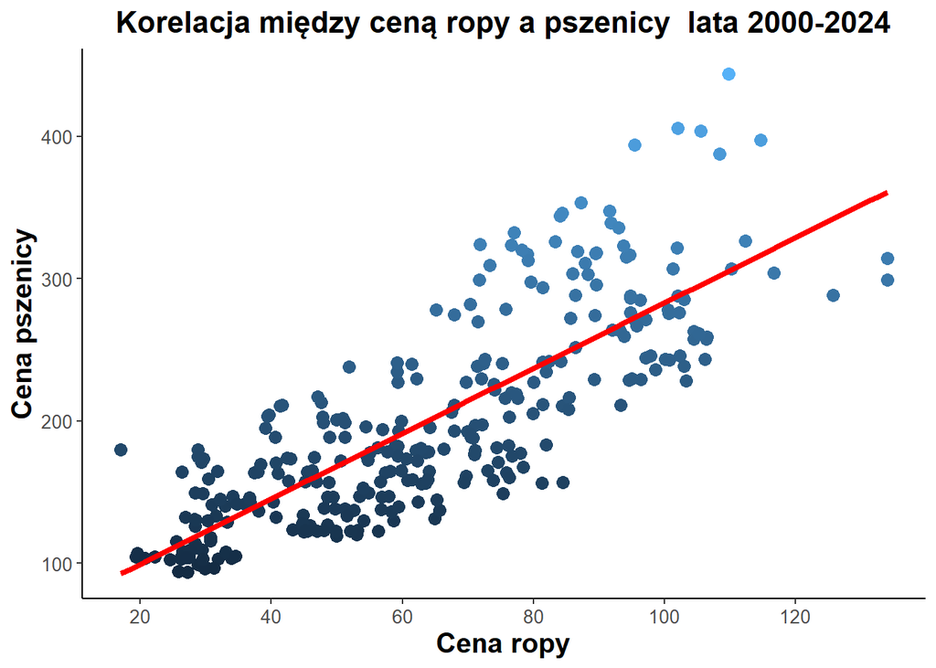

```r
ggplot(ropa_i_pszenica, aes(x = OIL_PRICE, y = Wheat_Price,color=Wheat_Price)) +
  geom_point(size = 3) +
  geom_smooth(method = "lm", color = "red",se = F, linewidth = 1.5) +
  labs(
    title = "Korelacja między ceną ropy a pszenicy  lata 2000-2024",
    x = "Cena ropy",
    y = "Cena pszenicy",
  ) +
  theme_classic() +
    scale_x_continuous(
    breaks = seq(0, max(ropa_i_pszenica$OIL_PRICE), by = 20)) +
  theme(
      axis.text.x = element_text(size = 10),
      axis.text.y = element_text(size = 10),
      plot.title = element_text(hjust = 0.5, size = 16, face = "bold"),
      axis.title.y = element_text(size = 15, face = "bold"),
      axis.title.x = element_text(size = 15, face = "bold"),
      legend.position = "none"
  )
```

```r
cor(dane_makroekonomiczne$OIL_PRICE,dane_makroekonomiczne$Wheat_Price)
```

```
## [1] 0.8058155
```

- W latach 2000-2024 wystepowala silna korelacja miedzy cenami ropy i pszenicy.

**Korelacja kwartalna**

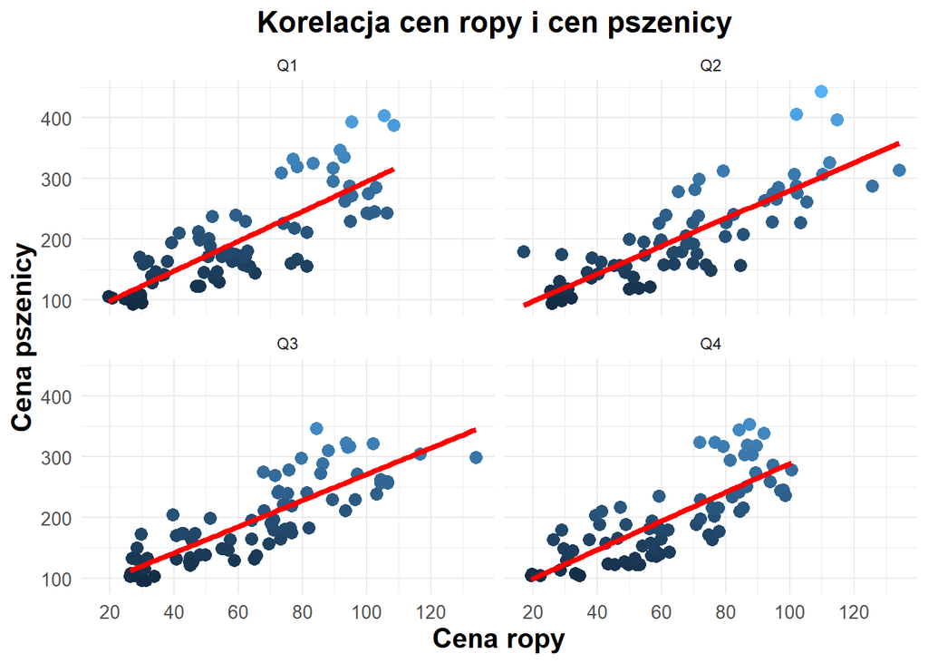

```r
ggplot(ropa_i_pszenica, aes(x = OIL_PRICE, y = Wheat_Price)) +
  geom_point(aes(color = Wheat_Price), size = 3) +
  geom_smooth(method = "lm", color = "red", se = F, linewidth = 1.5) +
  labs(
    title = "Korelacja cen ropy i cen pszenicy ",
    x = "Cena ropy",
    y = "Cena pszenicy",
  ) +
     scale_x_continuous(
    breaks = seq(0, max(ropa_i_pszenica$OIL_PRICE), by = 20)) +
  theme_minimal()+
  theme(
      axis.text.x = element_text(size = 10),
      axis.text.y = element_text(size = 10),
      plot.title = element_text(hjust = 0.5, size = 16, face = "bold"),
      axis.title.y = element_text(size = 15, face = "bold"),
      axis.title.x = element_text(size = 15, face = "bold"),
      legend.position = "none"
  )+ facet_wrap(~Quarter)
```

```r
(korelacja_kwartaly <- ropa_i_pszenica %>%
  group_by(Quarter) %>%
  summarize(korelacja = cor(OIL_PRICE, Wheat_Price)))
```

```
## # A tibble: 4 × 2
##   Quarter korelacja
##   <chr>       <dbl>
## 1 Q1          0.806
## 2 Q2          0.830
## 3 Q3          0.823
## 4 Q4          0.774
```

- Korelacja jest nadal silnie dodatnia w kazdym kwartale jednak rozni sie minimalnie miedzy kwartalami
- Q2 I Q3 moze miec najwieksza korelacje ze wzgledu na sezon wakacyjny i sezon zniw pszenicy.
- Brak sezowności kwartalnej.

**Korelacja miesieczna**

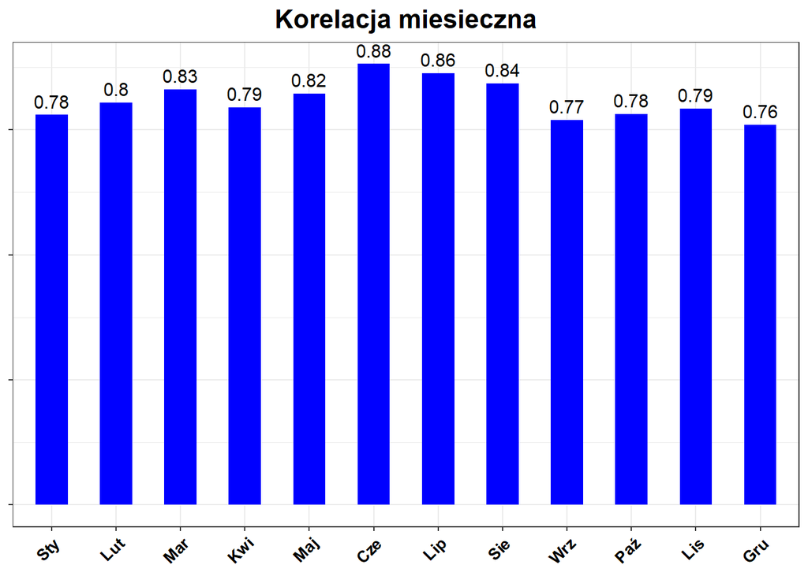

```r
korelacja_miesiace_2 <- ropa_i_pszenica %>%
  group_by(Month) %>%
  summarize(korelacja = cor(OIL_PRICE, Wheat_Price))


ggplot(korelacja_miesiace_2, aes(x = factor(Month), y = korelacja)) +
  geom_bar(stat = "identity",fill = "blue",width = 0.5) +
  geom_text(aes(label = round(korelacja, 2)), vjust = -0.5,
  size = 4) +
  labs(
    title = "Korelacja miesieczna",
    x = "Miesiąc",
    y = "Korelacja"
  ) +
  scale_x_discrete(labels = c("Sty", "Lut", "Mar", "Kwi", "Maj", "Cze",
                              "Lip", "Sie", "Wrz", "Paź", "Lis", "Gru")) +
  theme_bw() +
  theme(
      axis.text.x = element_text(angle = 45, hjust = 1, size = 10,face = "bold",color = "black"),
      plot.title = element_text(hjust = 0.5, size = 16, face = "bold"),
      axis.title.x = element_blank(),
      axis.title.y = element_blank(),
      axis.text.y = element_blank(),

  )
```

- Ponownie silne korelacje dodanie w kazdym miesiacu podobnie jak w kwartalach
- Brak miesiaca ktory moze nam zmieniac znaczaco korelacje np. na ujemna albo pod wzgledem sily na srednią lub słabą.
- Brak sezonwosci miesiecznej.

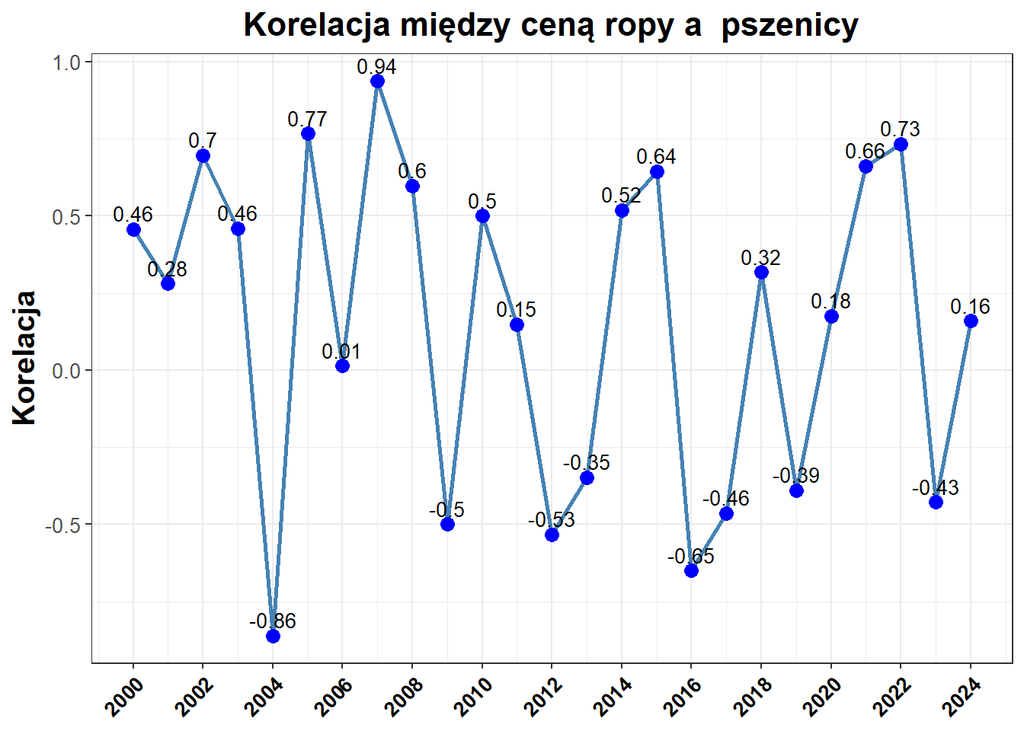

```r
korelacja_lata_ropa_pszenica <- ropa_i_pszenica %>%
  group_by(Year) %>%
  summarize(korelacja = cor(OIL_PRICE, Wheat_Price))



ggplot(korelacja_lata_ropa_pszenica, aes(x = Year, y = korelacja)) + geom_line(color = "steelblue", linewidth = 1) +
  geom_point(color = "blue", size = 3) +
  geom_text(aes(label = round(korelacja, 2)),
            vjust = -0.5,
            size = 3.5) +
  scale_x_continuous(breaks = seq(min(korelacja_lata_ropa_pszenica$Year),
                                  max(korelacja_lata_ropa_pszenica$Year), by = 2)) +
  labs( title = "Korelacja między ceną ropy a  pszenicy",
    x = "Rok",
    y = "Korelacja"
  ) +
  theme_bw() +
  theme(
      axis.text.x = element_text(angle = 45, hjust = 1, size = 10,face = "bold",color = "black"),
      axis.text.y = element_text(size = 10),
      plot.title = element_text(hjust = 0.5, size = 16, face = "bold"),
      axis.title.x = element_blank(),
      axis.title.y = element_text(size = 15, face = "bold"),
    )
```

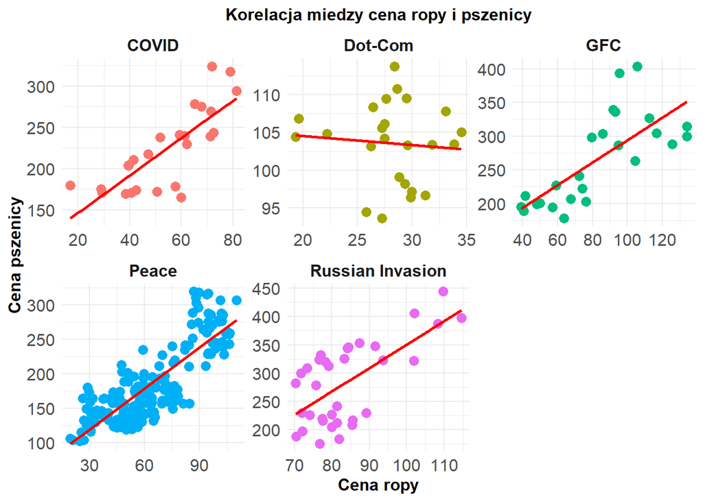

```r
ggplot(ropa_i_pszenica, aes(x = OIL_PRICE, y = Wheat_Price,color = Crisis)) +
  geom_point(size = 3) +
  facet_wrap(~Crisis, scales = "free") +
  geom_smooth(method = "lm", se = F, color = "red", linewidth = 1) +
  labs(
    title = "Korelacja miedzy cena ropy i pszenicy",
    x = "Cena ropy",
    y = "Cena pszenicy"
  ) +
  theme_minimal() +
  theme(
    plot.title = element_text(hjust = 0.5, size = 12, face = "bold"),
    axis.title = element_text(size = 12, face = "bold"),
    axis.text = element_text(size = 12),
    strip.text = element_text(size = 12, face = "bold"),
    legend.position = "none"
  )
```

```r
ropa_i_pszenica %>% group_by(Crisis)  %>%
  summarise(correlation =cor(OIL_PRICE,Wheat_Price))
```

```
## # A tibble: 5 × 2
##   Crisis           correlation
##   <chr>                  <dbl>
## 1 COVID                 0.789
## 2 Dot-Com              -0.0838
## 3 GFC                   0.738
## 4 Peace                 0.828
## 5 Russian Invasion      0.660
```

## **Podsumowanie tezy 6 i 7**

### **Podsumowujac**

- kryzys dot-com nie wplynal w zadnen sposob na ceny ropy i pszenicy stad brak korelacji.
- Kryzys GFC ,covid dzielil sie na 2 fazy w ktorych w jednej obie ceny rosly. Natomiast w drugiej obie spadaly stad silna korelacja.
- Inwazja rosji na ukraine spodowala wzrost cen ropy i pszenicy, pozniej ten wzrost zaczal wygasac stad srednia dodatnia korelacja .
- Nie dzielac na fazy spadek cen ropy i pszenicy spowodowal kryzys GFC i COVID. Poniewaz poprzez lockdowny spowodowal spadek cen Covid. A GFC przez bankructwo firm.

# **Wolumen i zwroty indeksu Nasdaq**

## **TEZA 8**

- Czy istnieje korelacje miedzy zwrotami z NQ a wolumenem?

## **TEZA 9**

- Podczas ktorego okresu liczba ujemnych zwrotow z NQ byla największa?

```r
dane_nq <-  dane_makroekonomiczne %>% select(DATE,Volume_bln,monthly_return_NQ,Year,Quarter,Crisis)

head(dane_nq)
```

```
##         DATE Volume_bln monthly_return_NQ Year Quarter  Crisis
## 1 2000-01-01   33.42106         -5.872639 2000      Q1 Dot-Com
## 2 2000-02-01   35.64470         18.571241 2000      Q1 Dot-Com
## 3 2000-03-01   43.20049         -3.380432 2000      Q1 Dot-Com
## 4 2000-04-01   35.14797        -14.110027 2000      Q2 Dot-Com
## 5 2000-05-01   30.83198        -13.466814 2000      Q2 Dot-Com
## 6 2000-06-01   33.35238         14.232929 2000      Q2 Dot-Com
```

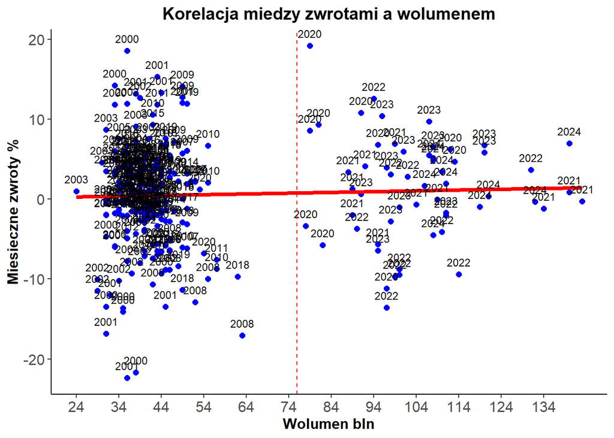

```r
ggplot(dane_nq, aes(x = round(Volume_bln), y = monthly_return_NQ)) +
  geom_point(color = "blue", size = 2) +
  geom_smooth(method = "lm", se = F, color = "red",linewidth = 1.5) +
  labs(
    title = "Korelacja miedzy zwrotami a wolumenem",
    x = "Wolumen bln",
    y = "Miesieczne zwroty %"
  ) +
  scale_x_continuous(breaks = seq(min(round(dane_nq$Volume_bln)), max(round(dane_nq$Volume_bln)), by = 10)) +
  theme_classic() +
  geom_text(aes(label=Year), vjust=-1, size = 3)+
  theme(
    plot.title = element_text(hjust = 0.5, size = 14, face = "bold"),
    axis.title = element_text(size = 12, face = "bold"),
    axis.text = element_text(size = 12),
    axis.line = element_line(linewidth = 0.5)
  ) +geom_vline(xintercept = 76,color="red",linetype="dashed")
```

```r
cor(round(dane_nq$Volume_bln),dane_nq$monthly_return_NQ)
```

```
## [1] 0.04009132
```

**podzielmy na lata**

```r
korelacja_lata <- dane_nq %>%
  group_by(Year) %>%
  summarize(korelacja = cor(Volume_bln, monthly_return_NQ))
```

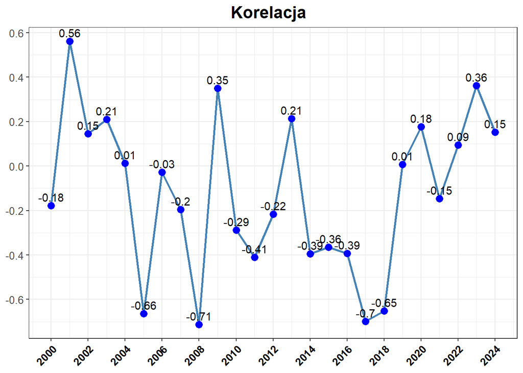

```r
korelacja_lata <- dane_nq %>%
  group_by(Year) %>%
  summarize(korelacja = cor(Volume_bln, monthly_return_NQ))


ggplot(korelacja_lata, aes(x = Year, y = korelacja)) +
  geom_line(color = "steelblue", linewidth = 1) +
  geom_point(color = "blue", size = 3) +
  geom_text(aes(label = round(korelacja, 2)),
            vjust = -0.5) +
  labs(
    title = "Korelacja  ",
    x = "Rok",
  ) +
  scale_x_continuous(breaks = seq(min(korelacja_lata$Year), max(korelacja_lata$Year), by = 2)) +
  scale_y_continuous(breaks = seq(-1, 1, by = 0.2)) +
  theme_bw() +
  theme(
      axis.text.x = element_text(angle = 45, hjust = 1, size = 10,face = "bold",color = "black"),
      axis.text.y = element_text(size = 10),
      plot.title = element_text(hjust = 0.5, size = 16, face = "bold"),
      axis.title.x = element_blank(),
      axis.title.y = element_blank()
    )
```

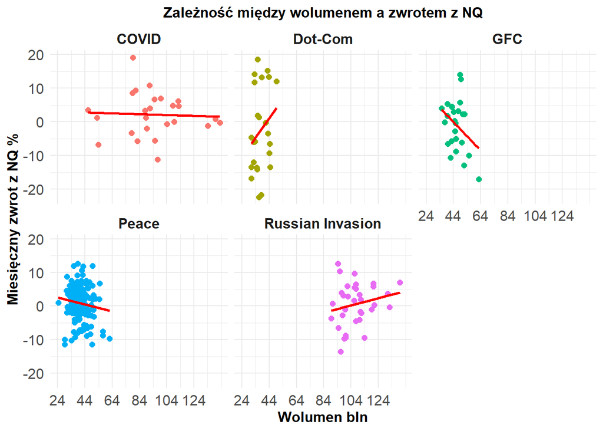

```r
ggplot(dane_nq, aes(Volume_bln, monthly_return_NQ,color = Crisis)) +
  geom_point(size = 2) +
  geom_smooth(method = "lm", se = FALSE, color = "red") +
  labs(
    title = "Zależność między wolumenem a zwrotem z NQ",
    x = "Wolumen bln",
    y = "Miesięczny zwrot z NQ %",
  ) +
  scale_x_continuous(breaks = seq(round(min(dane_nq$Volume_bln)), round(max(dane_nq$Volume_bln)), by = 20)) +
  facet_wrap(~Crisis) +
  theme_minimal() +
  theme(
     plot.title = element_text(hjust = 0.5, size = 12, face = "bold"),
    axis.title = element_text(size = 12, face = "bold"),
    axis.text = element_text(size = 12),
    strip.text = element_text(size = 12, face = "bold"),
    legend.position = "none"
  )
```

```r
dane_nq  %>% group_by(Crisis) %>%
  summarise(correlation = cor(Volume_bln,monthly_return_NQ))
```

```
## # A tibble: 5 × 2
##   Crisis           correlation
##   <chr>                  <dbl>
## 1 COVID                -0.0470
## 2 Dot-Com               0.244
## 3 GFC                  -0.333
## 4 Peace                -0.126
## 5 Russian Invasion      0.204
```

## **Podsumowanie Tezy 8**

```r
data_dist <- dane_nq %>% filter(Volume_bln>76)


data_dist %>% group_by(Year,Crisis) %>% summarise(quantity =n(), .groups = "drop")
```

```
## # A tibble: 5 × 3
##    Year Crisis           quantity
##   <dbl> <chr>               <int>
## 1  2020 COVID                  10
## 2  2021 COVID                  12
## 3  2022 Russian Invasion       12
## 4  2023 Russian Invasion       12
## 5  2024 Russian Invasion       10
```

```r
data_dist %>% group_by(Year,Crisis) %>% summarise(total_volume = sum(Volume_bln), .groups = "drop")
```

```
## # A tibble: 5 × 3
##    Year Crisis           total_volume
##   <dbl> <chr>                   <dbl>
## 1  2020 COVID                    909.
## 2  2021 COVID                   1291.
## 3  2022 Russian Invasion        1246.
## 4  2023 Russian Invasion        1243.
## 5  2024 Russian Invasion        1163.
```

- Najwieksze wolumeny (ponad 76 mld dolarow) mielismy w latach 2020-2024 co jest oczywiscie przyczyna pakietów stymulujacych jak i QE.
- Tylko 2 miesiace z 58 miesiecy z lat 2020-2024 mialy mniejsze mieseiczne wolumeny niz 76 mld.
- Schodzenie sukcesywne z podwyzszonego volumeu z 1,3 trillion na 1,2 trilion spadl o 100 mld z powodu QT i wysokich stop procentowych
- Dodatakowo widac na przestrzeni lat ze wolumen zwiększal sie co widac po polozeniu punktow na dotplocie z kryzysami.

```r
head(dane_nq)
```

```
##         DATE Volume_bln monthly_return_NQ Year Quarter  Crisis
## 1 2000-01-01   33.42106         -5.872639 2000      Q1 Dot-Com
## 2 2000-02-01   35.64470         18.571241 2000      Q1 Dot-Com
## 3 2000-03-01   43.20049         -3.380432 2000      Q1 Dot-Com
## 4 2000-04-01   35.14797        -14.110027 2000      Q2 Dot-Com
## 5 2000-05-01   30.83198        -13.466814 2000      Q2 Dot-Com
## 6 2000-06-01   33.35238         14.232929 2000      Q2 Dot-Com
```

```r
zwroty_ujemne <- dane_nq %>% filter(monthly_return_NQ<=0)

head(zwroty_ujemne)
```

```
##         DATE Volume_bln monthly_return_NQ Year Quarter  Crisis
## 1 2000-01-01   33.42106         -5.872639 2000      Q1 Dot-Com
## 2 2000-03-01   43.20049         -3.380432 2000      Q1 Dot-Com
## 3 2000-04-01   35.14797        -14.110027 2000      Q2 Dot-Com
## 4 2000-05-01   30.83198        -13.466814 2000      Q2 Dot-Com
## 5 2000-07-01   30.91611         -4.647409 2000      Q3 Dot-Com
## 6 2000-09-01   34.72733        -13.624398 2000      Q3 Dot-Com
```

```r
caly_okres <- length(dane_nq$Volume_bln)

ujemne <- length(zwroty_ujemne$Volume_bln)


ujemne/caly_okres
```

```
## [1] 0.4328859
```

```r
zwroty_ujemne %>% group_by(Crisis) %>% summarise(quantity = n())
```

```
## # A tibble: 5 × 2
##   Crisis           quantity
##   <chr>               <int>
## 1 COVID                  10
## 2 Dot-Com                15
## 3 GFC                    12
## 4 Peace                  77
## 5 Russian Invasion       15
```

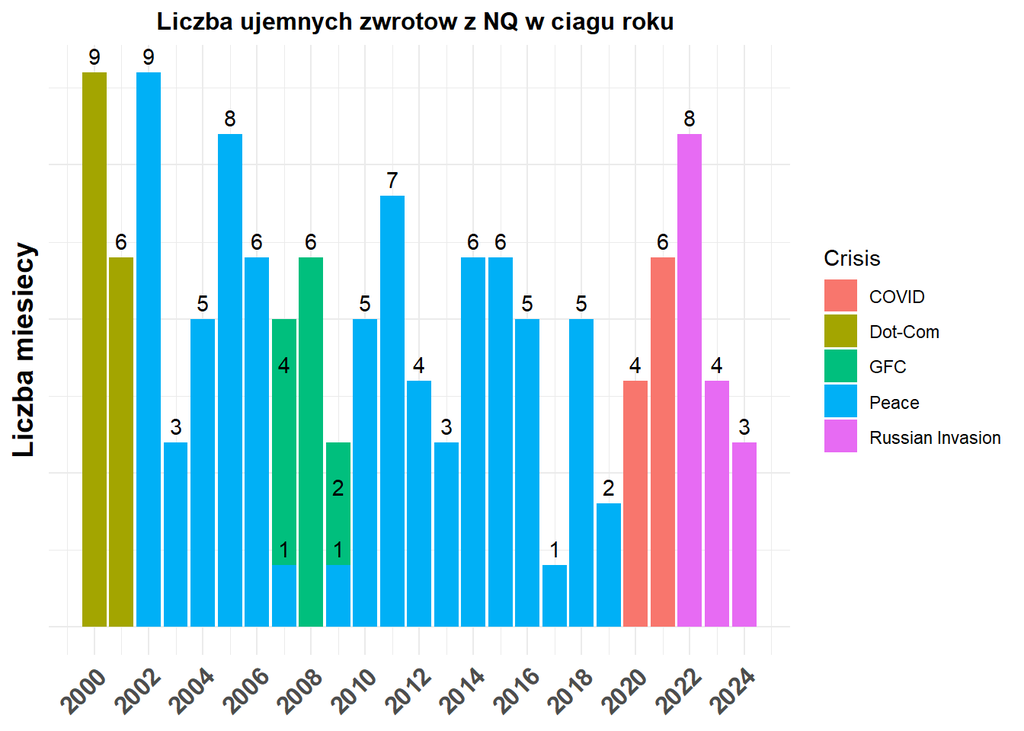

```r
liczba_lat <- zwroty_ujemne %>% group_by(Crisis,Year) %>% summarise(quantity = n(), .groups = "drop")


ggplot(liczba_lat,aes(Year,quantity,fill=Crisis)) +
  geom_col()+geom_text(aes(label=quantity,vjust=-0.5))+
 labs(
    title = "Liczba ujemnych zwrotow z NQ w ciagu roku ",
    x = "Rok",
    y = "Liczba miesiecy"
  ) +
  theme_minimal() +
  theme(
    plot.title = element_text(hjust = 0.5, size = 12, face = "bold"),
    axis.title.x = element_blank(),
    axis.title.y = element_text(size = 14, face = "bold"),
    axis.text.x = element_text(size = 12, face = "bold", angle = 45, hjust = 1),
    axis.text.y = element_blank()
  )+
   scale_x_continuous(breaks = seq(min(liczba_lat$Year), max(liczba_lat$Year), by = 2))
```

```r
zwroty_ujemne$typ <- cut(
  zwroty_ujemne$monthly_return_NQ,
  breaks = quantile(zwroty_ujemne$monthly_return_NQ, probs = 0:10 / 10),
  labels = c("Q1", "Q2", "Q3", "Q4", "Q5", "Q6", "Q7", "Q8", "Q9", "Q10"),
  include.lowest = TRUE
)



dane_dodatnie <- dane_nq %>% filter(monthly_return_NQ >= 0)

dane_dodatnie$typ <- cut(
  dane_dodatnie$monthly_return_NQ,
  breaks = quantile(dane_dodatnie$monthly_return_NQ, probs = 0:10 / 10),
  labels = c("Q1", "Q2", "Q3", "Q4", "Q5", "Q6", "Q7", "Q8", "Q9", "Q10"),
  include.lowest = TRUE
)

head(dane_dodatnie)
```

```
##         DATE Volume_bln monthly_return_NQ Year Quarter  Crisis typ
## 1 2000-02-01   35.64470         18.571241 2000      Q1 Dot-Com Q10
## 2 2000-06-01   33.35238         14.232929 2000      Q2 Dot-Com Q10
## 3 2000-08-01   33.22292         11.842757 2000      Q3 Dot-Com Q10
## 4 2001-01-01   49.39978         12.067533 2001      Q1 Dot-Com Q10
## 5 2001-04-01   42.64996         15.312607 2001      Q2 Dot-Com Q10
## 6 2001-06-01   36.57738          1.380491 2001      Q2 Dot-Com  Q2
```

```r
# zdecydowana wiekszosc jest malych ponad polowa jest w przedziale
zwroty_ujemne %>% group_by(typ) %>% summarise(quantity = n(),avg=mean(monthly_return_NQ), .groups = "drop")
```

```
## # A tibble: 10 × 3
##    typ   quantity     avg
##    <fct>    <int>   <dbl>
##  1 Q1          13 -14.9
##  2 Q2          13  -9.74
##  3 Q3          13  -7.46
##  4 Q4          13  -5.92
##  5 Q5          13  -3.91
##  6 Q6          12  -2.45
##  7 Q7          13  -1.85
##  8 Q8          13  -1.38
##  9 Q9          13  -0.749
## 10 Q10         13  -0.280
```

```r
dane_dodatnie %>% group_by(typ) %>% summarise(quantity = n(),avg=mean(monthly_return_NQ))
```

```
## # A tibble: 10 × 3
##    typ   quantity    avg
##    <fct>    <int>  <dbl>
##  1 Q1          17  0.503
##  2 Q2          17  1.21
##  3 Q3          17  2.00
##  4 Q4          17  2.84
##  5 Q5          17  3.48
##  6 Q6          16  4.05
##  7 Q7          17  5.00
##  8 Q8          17  6.14
##  9 Q9          17  8.02
## 10 Q10         17 13.3
```

# **Podsumowanie**

## **dlaczego na ogolne pytanie ekonomiczne najlepsza odpowiedz to : to zalezy?**

- Ponieważ to zalzey od wielu czynników, które mogą wpłynąć na wynik analizy, takich jak : kondycja rynku pracy, inflacja, sytuacja geopolityczna, okres, który weźmiemy pod uwagę, a także czynniki, których nawet nie uwzględnilem w mojej analizie, takie jak budżety państw, przepisy prawne, wybory prezydenckie, senackie etc.
- Dodatkowo, odpowiedź „to zależy” wynika z charakteru ekonomii jako nauki społecznej, która bada oddzialywanie wielu zmiennych na siebie. Na przykład różne szkoły ekonomiczne (keynesowska, monetarystyczna, austriacka) mogą inaczej interpretować dane zjawiska np co jest przyczyną inflacji, jak z nia walczyć etc.

## **Kryzys kryzysowi nie równy**

- Również warto zauwazyc ze nie kazdy kryzys charaktreryzuje sie tym samym, na ogół kryzysy dzieli się na popytowe (wywołane przez czynniki wewnętrzne państwa np. zbyt niskie stopy procentowe ktore prowadza do nadmiernego wzrostu konsumpcji i inwestycji) jak i kryzysy podażowe (wywołane przez czynniki zewnetrzne np. wzrost cen ropy ktory podnosi przede wszystkim koszty produkcji). Dot-com dla przykalu byl wywolany przez banke spekulacyjną wywołaną zbyt duzym optymizmem co do wyceny spolek internetowych. Kryzys z lat 2019-2021 byl wywolany natomaist przez pandemie COVID-19. Rosyjska agresja natomiast przez czynnik geopolityczny. A GFC przez masowe udzielane kredytow subrime i sekurtyzacje ich w MBS, czyli glownie przez krótkowzrocznosc zyskow korporacji.